# Deliverable 4: sensitivity analyses and publication figures

Preliminary · Heatwaves, ozone and mortality in Santiago, 2009-2020

Author

Amaru Agüero Jiménez

Published

November 25, 2026

Fourth deliverable of the data analysis: the sensitivity analyses and the figures for publication. The results are preliminary: they use working definitions that the principal investigator has not confirmed.

| Requested | Where |
| --- | --- |
| Sensitivity analyses | Sensitivity analyses and Lag structure: all the lags in one model |
| Publication figures, PDF and PNG | Publication figures |
| Final technical report | Pending |
| Documented GitHub repository | [README](https://github.com/AmaruSimonAgueroJimenez/Heatwave-ozone-mortality-Chile#readme) of the repository and R scripts |

The tables and the figures of this page can be downloaded: each table has an **Excel** button above it, and each figure a **PNG, 600 dpi** button below it. Each part names the scripts and the files behind its tables and figures.

# 1 Sensitivity analyses

*Script: `Code/40_sensitivity_analyses.R`. Tables: `Output/Tables/sensitivity_adjustment_or.csv`, `sensitivity_adjustment_interaction.csv`, `sensitivity_reference_or.csv`, `sensitivity_reference_interaction.csv` and `sensitivity_ozone_series.csv`.*

**WarningPreliminary**

Every analysis starts from the working definitions of the main models: heatwave P95, 2 days and ozone above the 75th percentile of the municipality in the delivered series. One element changes at a time.

## 1.1 Adjustment for other pollutants and humidity

The compound model is refitted with PM2.5, nitrogen dioxide and relative humidity as continuous covariates, each at the same lag as the exposure, one at a time and together. The covariates are the municipal series delivered with the ozone series (24-hour means, IDW). All the variants use the same deaths: the 135,215 non-accidental deaths whose referent days have every covariate (144 are left out).

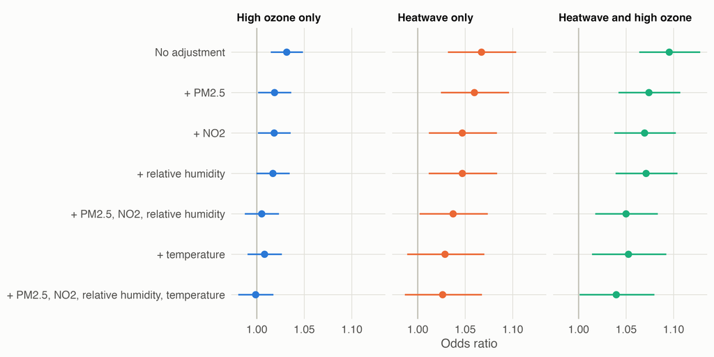

Figure 1: Odds ratios of non-accidental death by exposure category and adjustment, lag 0. Bars are 95% confidence intervals.

```r
plot_data <- headline[term %in% names(category_labels)]
plot_data[, `:=`(category = category_factor(term),
                 adjusted_for = factor(adjustment_label(adjustment), levels = rev(adjustment_levels)))]
ggplot(plot_data, aes(or, adjusted_for, colour = category)) +
  geom_vline(xintercept = 1, colour = ink$axis) +
  geom_pointrange(aes(xmin = or_low, xmax = or_high), linewidth = 0.6, size = 0.35) +
  facet_wrap(~category, nrow = 1) +
  scale_colour_manual(values = colour_compound[levels(plot_data$category)], guide = "none") +
  labs(x = "Odds ratio", y = NULL)
```

```r
table_data <- adjusted_or[lag == lag_main & term %in% names(category_labels)]
table_data[, `:=`(cause = cause_labels[outcome], category = category_factor(term),
                  adjusted_for = factor(adjustment_label(adjustment), levels = adjustment_levels),
                  value = ci(or, or_low, or_high))]
kable(dcast(table_data, cause + adjusted_for ~ category, value.var = "value"),
      col.names = c("Cause", "Adjusted for", levels(table_data$category)))
```

Table 1: Odds ratios (95% confidence interval) by adjustment, lag 0.

| Cause | Adjusted for | High ozone only | Heatwave only | Heatwave and high ozone |
| --- | --- | --- | --- | --- |
| Cardiopulmonary | No adjustment | 1.018 (0.992 to 1.046) | 1.067 (1.011 to 1.128) | 1.056 (1.007 to 1.107) |
| Cardiopulmonary | + PM2.5 | 1.003 (0.975 to 1.031) | 1.058 (1.002 to 1.118) | 1.030 (0.981 to 1.082) |
| Cardiopulmonary | + NO2 | 1.004 (0.977 to 1.032) | 1.046 (0.989 to 1.106) | 1.029 (0.980 to 1.081) |
| Cardiopulmonary | + relative humidity | 1.009 (0.981 to 1.037) | 1.054 (0.997 to 1.115) | 1.040 (0.991 to 1.093) |
| Cardiopulmonary | + PM2.5, NO2, relative humidity | 0.994 (0.966 to 1.023) | 1.042 (0.985 to 1.102) | 1.015 (0.964 to 1.067) |
| Cardiopulmonary | + temperature | 0.995 (0.967 to 1.024) | 1.039 (0.975 to 1.108) | 1.026 (0.966 to 1.089) |
| Cardiopulmonary | + PM2.5, NO2, relative humidity, temperature | 0.986 (0.957 to 1.016) | 1.038 (0.973 to 1.106) | 1.013 (0.953 to 1.077) |
| Non-accidental | No adjustment | 1.032 (1.015 to 1.049) | 1.067 (1.032 to 1.104) | 1.095 (1.064 to 1.128) |
| Non-accidental | + PM2.5 | 1.019 (1.001 to 1.036) | 1.060 (1.024 to 1.096) | 1.074 (1.042 to 1.107) |
| Non-accidental | + NO2 | 1.018 (1.001 to 1.036) | 1.047 (1.012 to 1.083) | 1.069 (1.038 to 1.102) |
| Non-accidental | + relative humidity | 1.017 (1.000 to 1.035) | 1.047 (1.012 to 1.084) | 1.071 (1.039 to 1.104) |
| Non-accidental | + PM2.5, NO2, relative humidity | 1.005 (0.987 to 1.023) | 1.037 (1.002 to 1.074) | 1.050 (1.017 to 1.083) |
| Non-accidental | + temperature | 1.008 (0.990 to 1.026) | 1.029 (0.989 to 1.070) | 1.052 (1.014 to 1.092) |
| Non-accidental | + PM2.5, NO2, relative humidity, temperature | 0.999 (0.980 to 1.017) | 1.026 (0.986 to 1.068) | 1.040 (1.001 to 1.080) |

With the three covariates together the odds ratio of high-ozone-only days goes from 1.032 (1.015 to 1.049) to 1.005 (0.987 to 1.023), that of heatwave-only days from 1.067 (1.032 to 1.104) to 1.037 (1.002 to 1.074) and that of days with both from 1.095 (1.064 to 1.128) to 1.050 (1.017 to 1.083). Once PM2.5, nitrogen dioxide and humidity are in the model, the odds ratio of high ozone alone cannot be told apart from 1; the odds ratios of heatwave days are smaller and their intervals still exclude 1.

```r
covariates <- headline[term %in% names(increments)]
covariates[, `:=`(adjusted_for = factor(adjustment_label(adjustment), levels = adjustment_levels),
                  covariate = sprintf("%s, per %s %s", pollutant_labels[term], increment,
                                      c(pm25 = "µg/m³", no2 = "ppb",
                                        hum = "percentage points")[term]),
                  value = ci(or, or_low, or_high))]
kable(covariates[order(adjusted_for), .(adjusted_for, covariate, value)],
      col.names = c("Model", "Covariate", "Odds ratio (95% CI)"))
```

Table 2: Odds ratios of the covariates, non-accidental mortality, lag 0.

| Model | Covariate | Odds ratio (95% CI) |
| --- | --- | --- |
| + PM2.5 | PM2.5, per 10 µg/m³ | 1.027 (1.016 to 1.038) |
| + NO2 | NO2, per 10 ppb | 1.051 (1.035 to 1.068) |
| + relative humidity | relative humidity, per 10 percentage points | 0.982 (0.975 to 0.988) |
| + PM2.5, NO2, relative humidity | PM2.5, per 10 µg/m³ | 1.019 (1.007 to 1.033) |
| + PM2.5, NO2, relative humidity | NO2, per 10 ppb | 1.021 (1.000 to 1.043) |
| + PM2.5, NO2, relative humidity | relative humidity, per 10 percentage points | 0.985 (0.978 to 0.993) |
| + PM2.5, NO2, relative humidity, temperature | PM2.5, per 10 µg/m³ | 1.018 (1.005 to 1.031) |
| + PM2.5, NO2, relative humidity, temperature | NO2, per 10 ppb | 1.015 (0.993 to 1.037) |
| + PM2.5, NO2, relative humidity, temperature | relative humidity, per 10 percentage points | 0.991 (0.983 to 0.999) |

### 1.1.1 Interaction after adjustment

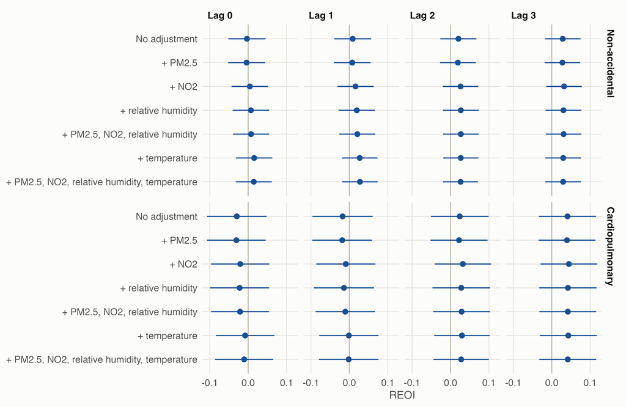

Figure 2: REOI by adjustment and lag. Bars are 95% confidence intervals; zero means no additive interaction.

```r
reoi <- adjusted_int[measure == "REOI"]
reoi[, `:=`(cause = factor(cause_labels[outcome], levels = cause_labels[unique(outcome)]),
            adjusted_for = factor(adjustment_label(adjustment), levels = rev(adjustment_levels)))]
ggplot(reoi, aes(estimate, adjusted_for)) +
  geom_vline(xintercept = 0, colour = ink$axis) +
  geom_pointrange(aes(xmin = low, xmax = high), colour = ramp_blue[6], linewidth = 0.5, size = 0.3) +
  facet_grid(cause ~ paste("Lag", lag)) +
  scale_x_continuous(breaks = c(-0.1, 0, 0.1)) +
  labs(x = "REOI", y = NULL)
```

```r
reoi_range <- reoi[, .(lowest = min(estimate), highest = max(estimate),
                       excluding_zero = sum(low > 0 | high < 0), fits = .N)]
```

The REOI stays between -0.031 and 0.045 across the 56 combinations of cause, lag and adjustment, and its 95% interval includes zero in all of them.

## 1.2 Adjustment for temperature

This analysis is not in the plan. The heatwave indicator is a threshold on temperature, and ozone is higher on hot days, so part of the odds ratio of high-ozone days may be temperature below the heatwave threshold. The compound model is refitted with the daily maximum temperature of the same day, as a natural cubic spline of its percentile among the warm-season days of the municipality (knots at the 50th and 90th percentiles). Percentiles are used because the municipal temperature series are area means whose level differs by more than 10 °C between municipalities.

```r
temperature_rows <- headline[adjustment %in% c("none", "temperature",
                                               paste(c(names(increments), "temperature"), collapse = " + "))]
temperature_rows[, `:=`(adjusted_for = factor(adjustment_label(adjustment), levels = adjustment_levels),
                        row = fifelse(term %in% names(category_labels), category_labels[term],
                                      sub("temperature_p", "Temperature, percentile ", term)),
                        value = ci(or, or_low, or_high))]
temperature_rows <- temperature_rows[term %in% names(category_labels) | grepl("^temperature_p", term)]
temperature_rows[grepl("^Temperature", row), row := paste(row, "against", temperature$reference)]
kable(dcast(temperature_rows, factor(row, levels = unique(row)) ~ adjusted_for, value.var = "value"),
      col.names = c("Term", levels(droplevels(temperature_rows$adjusted_for))))
```

Table 3: Compound model adjusted for the temperature of the same day, non-accidental mortality, lag 0.

| Term | No adjustment | + temperature | + PM2.5, NO2, relative humidity, temperature |
| --- | --- | --- | --- |
| Heatwave only | 1.067 (1.032 to 1.104) | 1.029 (0.989 to 1.070) | 1.026 (0.986 to 1.068) |
| High ozone only | 1.032 (1.015 to 1.049) | 1.008 (0.990 to 1.026) | 0.999 (0.980 to 1.017) |
| Heatwave and high ozone | 1.095 (1.064 to 1.128) | 1.052 (1.014 to 1.092) | 1.040 (1.001 to 1.080) |
| Temperature, percentile 90 against 50 |  | 1.032 (1.010 to 1.054) | 1.018 (0.995 to 1.041) |
| Temperature, percentile 95 against 50 |  | 1.037 (1.009 to 1.067) | 1.020 (0.990 to 1.050) |
| Temperature, percentile 99 against 50 |  | 1.042 (1.005 to 1.081) | 1.021 (0.983 to 1.060) |

With temperature in the model the heatwave indicator measures what heatwave days add beyond the temperature of the day itself, a different question from the one of the plan. Read that way, days with both exposures keep an odds ratio of 1.052 (1.014 to 1.092), heatwave-only days 1.029 (0.989 to 1.070) and high-ozone-only days 1.008 (0.990 to 1.026).

## 1.3 Reference category: three ozone levels

The plan words the reference category as “non-heatwave day and low ozone (at or below the 50th percentile)” and the exposed categories with ozone above the 75th percentile. The headline model splits the days at one cut-off, so its reference includes the days between the two percentiles. Here ozone has three levels: low (at or below the 50th percentile), medium and high (above the 75th), and the reference is no heatwave with low ozone.

```r
r <- reference_or[outcome == "non_accidental" & lag == lag_main]
r[, `:=`(heatwave_day = fifelse(heatwave == 1, "Heatwave", "No heatwave"),
         level = factor(ozone_level, levels = c("low", "medium", "high")),
         value = ci(or, or_low, or_high))]
reference_row <- data.table(heatwave_day = "No heatwave", level = factor("low", levels = levels(r$level)),
                            deaths = unique(r$deaths_reference), value = "1 (reference)")
r <- rbind(r[, .(heatwave_day, level, deaths, value)], reference_row)
setorder(r, -heatwave_day, level)
kable(r, format.args = list(big.mark = ","),
      col.names = c("Heatwave", "Ozone level", "Deaths", "Odds ratio (95% CI)"))
```

Table 4: Odds ratios with three ozone levels, non-accidental mortality, lag 0. Reference: no heatwave and low ozone.

| Heatwave | Ozone level | Deaths | Odds ratio (95% CI) |
| --- | --- | --- | --- |
| No heatwave | low | 64,616 | 1 (reference) |
| No heatwave | medium | 30,883 | 1.034 (1.017 to 1.050) |
| No heatwave | high | 27,597 | 1.046 (1.027 to 1.064) |
| Heatwave | low | 1,802 | 1.089 (1.031 to 1.150) |
| Heatwave | medium | 3,117 | 1.074 (1.030 to 1.120) |
| Heatwave | high | 7,344 | 1.110 (1.077 to 1.144) |

```r
ri <- reference_int[measure == "REOI"]
ri[, `:=`(cause = cause_labels[outcome], value = ci(estimate, low, high))]
kable(dcast(ri, cause + contrast ~ paste("Lag", lag), value.var = "value"),
      col.names = c("Cause", "Contrast", paste("Lag", sort(unique(ri$lag)))))
```

Table 5: REOI with three ozone levels: high ozone and medium ozone, each against low ozone.

| Cause | Contrast | Lag 0 | Lag 1 | Lag 2 | Lag 3 |
| --- | --- | --- | --- | --- | --- |
| Cardiopulmonary | high against low ozone | -0.031 (-0.138 to 0.077) | 0.028 (-0.079 to 0.135) | 0.014 (-0.091 to 0.119) | 0.009 (-0.096 to 0.113) |
| Cardiopulmonary | medium against low ozone | -0.018 (-0.137 to 0.101) | 0.067 (-0.051 to 0.185) | -0.015 (-0.129 to 0.099) | -0.043 (-0.155 to 0.070) |
| Non-accidental | high against low ozone | -0.025 (-0.093 to 0.043) | 0.024 (-0.042 to 0.090) | 0.014 (-0.050 to 0.079) | -0.002 (-0.067 to 0.063) |
| Non-accidental | medium against low ozone | -0.048 (-0.122 to 0.025) | 0.021 (-0.051 to 0.093) | -0.014 (-0.085 to 0.057) | -0.044 (-0.114 to 0.027) |

```r
h1_low <- reference_or[outcome == "non_accidental" & lag == lag_main & term == "h1_low"]
```

The conclusion does not change. Heatwave days with low ozone are few (1,802 deaths), so their odds ratio, 1.089 (1.031 to 1.150), is less precise than in the headline model.

## 1.4 Ozone series

The same model with each ozone series of the exposure dataset: the delivered series in its two versions (values within the operational period of each monitor, and all values), the 24-hour mean rebuilt from the validated hourly records and the daily maximum 8-hour mean (MDA8), each interpolated by IDW and by ordinary kriging. The cut-off is always the 75th percentile of the municipality.

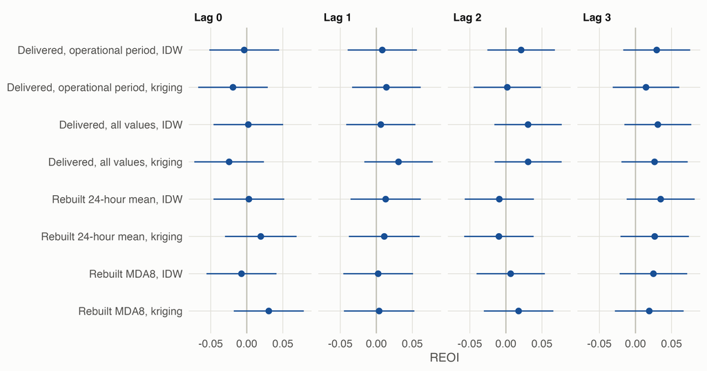

Figure 3: REOI by ozone series and lag, non-accidental mortality. Bars are 95% confidence intervals.

```r
series_levels <- unique(series_fits$series_label)
s <- series_fits[outcome == "non_accidental"]
s[, series_label := factor(series_label, levels = rev(series_levels))]
ggplot(s, aes(estimate_reoi, series_label)) +
  geom_vline(xintercept = 0, colour = ink$axis) +
  geom_pointrange(aes(xmin = low_reoi, xmax = high_reoi), colour = ramp_blue[6],
                  linewidth = 0.5, size = 0.3) +
  facet_wrap(~paste("Lag", lag), nrow = 1) +
  labs(x = "REOI", y = NULL)
```

```r
st <- series_fits[outcome == "non_accidental" & lag == lag_main,
             .(series_label, deaths_e11,
               e01 = ci(or_e01, or_low_e01, or_high_e01), e10 = ci(or_e10, or_low_e10, or_high_e10),
               e11 = ci(or_e11, or_low_e11, or_high_e11),
               reoi = ci(estimate_reoi, low_reoi, high_reoi))]
kable(st, format.args = list(big.mark = ","),
      col.names = c("Ozone series", "Deaths on days with both", category_labels[["e01"]],
                    category_labels[["e10"]], category_labels[["e11"]], "REOI"))
```

Table 6: Odds ratios and REOI (95% confidence interval) by ozone series, non-accidental mortality, lag 0.

| Ozone series | Deaths on days with both | High ozone only | Heatwave only | Heatwave and high ozone | REOI |
| --- | --- | --- | --- | --- | --- |
| Delivered, operational period, IDW | 7,344 | 1.032 (1.015 to 1.049) | 1.067 (1.032 to 1.104) | 1.096 (1.064 to 1.128) | -0.004 (-0.052 to 0.045) |
| Delivered, operational period, kriging | 7,014 | 1.033 (1.016 to 1.050) | 1.075 (1.040 to 1.111) | 1.089 (1.057 to 1.122) | -0.019 (-0.067 to 0.029) |
| Delivered, all values, IDW | 7,279 | 1.034 (1.017 to 1.051) | 1.064 (1.029 to 1.100) | 1.100 (1.068 to 1.133) | 0.002 (-0.046 to 0.050) |
| Delivered, all values, kriging | 6,989 | 1.036 (1.019 to 1.053) | 1.077 (1.042 to 1.113) | 1.088 (1.057 to 1.121) | -0.024 (-0.073 to 0.024) |
| Rebuilt 24-hour mean, IDW | 7,970 | 1.027 (1.010 to 1.044) | 1.063 (1.025 to 1.102) | 1.093 (1.063 to 1.124) | 0.003 (-0.046 to 0.052) |
| Rebuilt 24-hour mean, kriging | 8,087 | 1.041 (1.024 to 1.058) | 1.047 (1.009 to 1.086) | 1.107 (1.077 to 1.138) | 0.019 (-0.030 to 0.069) |
| Rebuilt MDA8, IDW | 7,943 | 1.030 (1.014 to 1.047) | 1.066 (1.029 to 1.105) | 1.089 (1.060 to 1.119) | -0.007 (-0.056 to 0.041) |
| Rebuilt MDA8, kriging | 8,058 | 1.031 (1.015 to 1.048) | 1.041 (1.004 to 1.080) | 1.103 (1.074 to 1.134) | 0.031 (-0.018 to 0.079) |

```r
series_range <- series_fits[, .(lowest = min(estimate_reoi), highest = max(estimate_reoi),
                           excluding_zero = sum(low_reoi > 0 | high_reoi < 0), fits = .N)]
```

Across the 64 fits (two causes, eight series, four lags) the REOI ranges from -0.062 to 0.071 and its 95% interval includes zero in all of them. The choice between the delivered series and the series rebuilt from the hourly records, or between IDW and kriging, changes which days are classified as high ozone (validation of the ozone exposure) but not the answer to the interaction question.

## 1.5 Heatwave and ozone definitions

The grid of the 15 heatwave definitions and the ozone cut-offs is in deliverable 3. The lags 2 and 3 of that grid, where part of the cells show a positive REOI, are examined in the lag structure below.

# 2 Lag structure: all the lags in one model

*Script: `Code/41_distributed_lag_models.R`. Tables: `Output/Tables/lags_compound_or.csv`, `lags_compound_interaction.csv`, `lags_grid.csv`, `lags_temperature_or.csv`, `lags_temperature_curve.csv` and `lags_ozone_or.csv`. For comparison: `models_main_or.csv` and `models_grid.csv` of `Code/30_models_main.R`.*

**WarningPreliminary**

Working definitions as in the main models: heatwave P95, 2 days, ozone above the 75th percentile of the municipality in the delivered series. The form in which temperature enters the models of this section is a proposal, marked `TO CONFIRM` in `config/config.yml`.

## 2.1 Why

The models of deliverable 3 and of the sensitivity analyses take one lag at a time: the exposure of the day of death, or of one, two or three days before. Exposures of consecutive days are not independent. A heatwave lasts at least two days by definition and ozone episodes last several days, so the odds ratio of the exposure two days before also carries the effect of the exposure one day before and on the day.

```r
columns <- c(paste0(heatwave_main, "_lag", lags), paste0(ozone_flag_main, "_lag", lags))
x <- fread(derived_path("exposure_lagged.csv"), select = columns)
hw <- function(k) x[[paste0(heatwave_main, "_lag", k)]]
oz <- function(k) x[[paste0(ozone_flag_main, "_lag", k)]]
persistence <- rbindlist(lapply(setdiff(lags, 0), function(k) data.table(
  days_before = k,
  heatwave = 100 * mean(hw(k)[hw(0) == 1] == 1, na.rm = TRUE),
  high_ozone = 100 * mean(oz(k)[oz(0) == 1] == 1, na.rm = TRUE),
  both = 100 * mean((hw(k) == 1 & oz(k) == 1)[hw(0) == 1 & oz(0) == 1], na.rm = TRUE)
)))
kable(persistence, digits = 0,
      col.names = c("Days before", "Heatwave", "High ozone", "Heatwave and high ozone"))
```

Table 7: Persistence of the exposure: of the municipality-days in each state, share (%) in the same state one, two and three days before. Referent days of the case-crossover dataset.

| Days before | Heatwave | High ozone | Heatwave and high ozone |
| --- | --- | --- | --- |
| 1 | 54 | 52 | 42 |
| 2 | 31 | 40 | 25 |
| 3 | 23 | 38 | 19 |

In this section the exposures of the four lags enter the same model, with one coefficient per lag and no constraint on their shape. Each lag-specific odds ratio is then adjusted for the other lags, and the sum of the coefficients gives a cumulative odds ratio over the window.

## 2.2 Exposure categories

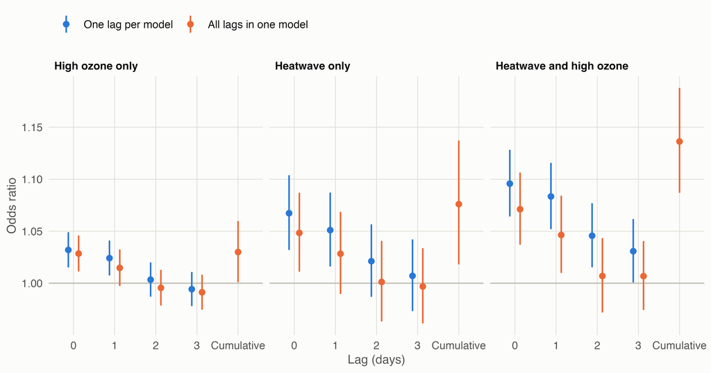

Figure 4: Odds ratios of non-accidental death by exposure category and lag: one lag per model (deliverable 3) and all the lags in one model. Bars are 95% confidence intervals.

```r
single <- main_or[outcome == "non_accidental" & subgroup == "all" & model == "compound",
                  .(category = term, lag = as.character(lag), or, or_low, or_high,
                    model = "One lag per model")]
together <- lag_or[outcome == "non_accidental", .(category, lag, or, or_low, or_high,
                                                 model = "All lags in one model")]
both <- rbind(single, together)
both[, `:=`(category = category_factor(category), lag = lag_factor(lag),
            model = factor(model, levels = names(colour_model)))]
ggplot(both, aes(lag, or, colour = model)) +
  geom_hline(yintercept = 1, colour = ink$axis) +
  geom_pointrange(aes(ymin = or_low, ymax = or_high), position = position_dodge(width = 0.5),
                  linewidth = 0.6, size = 0.3) +
  facet_wrap(~category, nrow = 1) +
  scale_colour_manual(values = colour_model) +
  labs(x = "Lag (days)", y = "Odds ratio", colour = NULL)
```

```r
t1 <- copy(lag_or)
t1[, `:=`(cause = cause_labels[outcome], category = category_factor(category),
          lag = lag_factor(lag), value = ci(or, or_low, or_high))]
kable(dcast(t1, cause + lag ~ category, value.var = "value"),
      col.names = c("Cause", "Lag", levels(t1$category)))
```

Table 8: Odds ratios (95% confidence interval) with all the lags in one model.

| Cause | Lag | High ozone only | Heatwave only | Heatwave and high ozone |
| --- | --- | --- | --- | --- |
| Cardiopulmonary | 0 | 1.018 (0.991 to 1.046) | 1.032 (0.973 to 1.094) | 1.023 (0.971 to 1.078) |
| Cardiopulmonary | 1 | 1.007 (0.979 to 1.035) | 1.085 (1.020 to 1.153) | 1.073 (1.014 to 1.137) |
| Cardiopulmonary | 2 | 0.985 (0.958 to 1.013) | 0.982 (0.923 to 1.045) | 0.986 (0.931 to 1.044) |
| Cardiopulmonary | 3 | 0.992 (0.965 to 1.019) | 0.989 (0.933 to 1.048) | 1.016 (0.963 to 1.071) |
| Cardiopulmonary | Cumulative | 1.002 (0.957 to 1.049) | 1.086 (0.994 to 1.187) | 1.100 (1.024 to 1.182) |
| Non-accidental | 0 | 1.028 (1.011 to 1.046) | 1.048 (1.011 to 1.087) | 1.071 (1.037 to 1.106) |
| Non-accidental | 1 | 1.015 (0.997 to 1.032) | 1.028 (0.990 to 1.069) | 1.046 (1.010 to 1.084) |
| Non-accidental | 2 | 0.996 (0.979 to 1.013) | 1.001 (0.963 to 1.041) | 1.007 (0.972 to 1.043) |
| Non-accidental | 3 | 0.991 (0.975 to 1.008) | 0.997 (0.961 to 1.034) | 1.007 (0.974 to 1.041) |
| Non-accidental | Cumulative | 1.030 (1.001 to 1.060) | 1.076 (1.018 to 1.137) | 1.136 (1.087 to 1.188) |

```r
na <- lag_or[outcome == "non_accidental"]
pick <- function(category_value, lag_value) {
  na[category == category_value & lag == lag_value, ci(or, or_low, or_high)]
}
later <- na[lag %in% c("2", "3")]
```

With the four lags together the associations sit on the day of exposure and the day after. For days with both exposures the odds ratio is 1.071 (1.037 to 1.106) at lag 0 and 1.046 (1.010 to 1.084) at lag 1; at lags 2 and 3 the odds ratios of the three categories lie between 0.991 and 1.007. With these definitions, the associations that the single-lag models show at lags 2 and 3 are the exposure of the days before, carried by its persistence. Over the four days the cumulative odds ratio is 1.136 (1.087 to 1.188) for days with both exposures, 1.076 (1.018 to 1.137) for heatwave only and 1.030 (1.001 to 1.060) for high ozone only. A cumulative odds ratio compares four consecutive days in the category with four consecutive days with neither exposure.

### 2.2.1 Interaction over the window

```r
t2 <- copy(lag_int)
# The causes are the columns: a factor fixes their order, and the header is
# taken from the reshaped table itself
t2[, `:=`(cause = factor(cause_labels[outcome], levels = cause_labels[unique(outcome)]),
          measure = factor(measure, levels = unique(measure)),
          value = ifelse(measure == "S" & (is.na(low) | high / low > 1e3),
                         paste(fmt(estimate, 3), "(interval not informative)"),
                         ci(estimate, low, high)))]
wide <- dcast(t2, measure ~ cause, value.var = "value")
kable(wide, col.names = c("Measure", names(wide)[-1]))
```

Table 9: Additive and multiplicative interaction computed from the cumulative odds ratios (lags 0 to 3 together). REOI and AP have null value 0; S and the multiplicative ratio have null value 1.

| Measure | Non-accidental | Cardiopulmonary |
| --- | --- | --- |
| REOI | 0.030 (-0.055 to 0.116) | 0.012 (-0.124 to 0.148) |
| AP | 0.027 (-0.048 to 0.101) | 0.011 (-0.113 to 0.134) |
| S | 1.286 (0.610 to 2.713) | 1.134 (0.258 to 4.985) |
| multiplicative ratio | 1.025 (0.948 to 1.109) | 1.011 (0.891 to 1.146) |

```r
reoi <- lag_int[measure == "REOI"]
```

The cumulative REOI is 0.030 (-0.055 to 0.116) for non-accidental mortality and 0.012 (-0.124 to 0.148) for cardiopulmonary mortality. Both intervals include zero: with the working definitions there is no additive interaction at any lag or over the window.

### 2.2.2 Across the definitions

The same model for the 15 heatwave definitions and the three cut-offs of the delivered ozone series, fitted twice: as above, and with the temperature of every lag in the model (the spline of the next section), to see whether an interaction between the two indicators is temperature that the heatwave threshold leaves out. The REOI of each lag comes from the three coefficients of that lag; the cumulative REOI from the cumulative odds ratios.

```r
adjustment_labels <- c(none = "All lags in one model", temperature = "All lags and temperature")
g <- lag_grid[outcome == "non_accidental" & estimable == TRUE]
g[, `:=`(cutoff = paste0("> P", sub(".*_gt_p", "", ozone)),
         definition = factor(heatwave_label(heatwave),
                             levels = rev(heatwave_label(unique(lag_grid$heatwave)))),
         panel = factor(lag, levels = lag_levels, labels = c(paste("Lag", lags), "Cumulative")),
         fitted = factor(adjustment_labels[adjustment], levels = adjustment_labels),
         excludes_zero = low_reoi > 0 | high_reoi < 0)]
limit <- 0.15
ggplot(g, aes(cutoff, definition, fill = estimate_reoi)) +
  geom_tile(colour = ink$surface, linewidth = 0.8) +
  geom_point(data = g[excludes_zero == TRUE], size = 1.2, colour = ink$primary) +
  facet_grid(fitted ~ panel) +
  scale_fill_gradient2(low = diverging[["low"]], mid = diverging[["mid"]], high = diverging[["high"]],
                       midpoint = 0, limits = c(-limit, limit), oob = scales::squish, name = "REOI") +
  labs(x = "Ozone cut-off (municipality percentile)", y = NULL) +
  theme(panel.grid.major = element_blank(), legend.position = "right",
        legend.justification = "center")
```

[figure not shown]

Figure 5: REOI for non-accidental mortality from the model with all the lags, by lag and cumulative, across heatwave definitions (rows) and ozone cut-offs (columns), without and with temperature in the model. A dot marks the cells whose 95% interval excludes zero. Colour scale limited to plus or minus 0.15.

```r
model_levels <- c("One lag per model", adjustment_labels)
count_cells <- function(dt, label) {
  dt[estimable == TRUE, .(model = label, positive = sum(estimate_reoi > 0), above = sum(low_reoi > 0),
                          below = sum(high_reoi < 0), median_reoi = median(estimate_reoi)),
     by = .(outcome, lag)]
}
one_lag <- single_grid[grepl(paste0("^", ozone_series, "_gt_p"), ozone) &
                         outcome %in% unique(lag_grid$outcome)]
one_lag[, lag := as.character(lag)]
cells <- rbind(count_cells(one_lag, "One lag per model"),
               count_cells(lag_grid[adjustment == "none"], adjustment_labels[["none"]]),
               count_cells(lag_grid[adjustment == "temperature"], adjustment_labels[["temperature"]]))
cells[, `:=`(cause = factor(cause_labels[outcome], levels = cause_labels[unique(outcome)]),
             lag = lag_factor(lag), model = factor(model, levels = model_levels))]
setorder(cells, cause, lag, model)
kable(cells[, .(cause, lag, model, positive, above, below, median_reoi)],
      digits = c(0, 0, 0, 0, 0, 0, 3),
      col.names = c("Cause", "Lag", "Model", "REOI above 0", "Interval above 0",
                    "Interval below 0", "Median REOI"))
```

Table 10: Cells of the grid (45 per cause) by the sign of the REOI and by whether its 95% interval lies above or below zero.

| Cause | Lag | Model | REOI above 0 | Interval above 0 | Interval below 0 | Median REOI |
| --- | --- | --- | --- | --- | --- | --- |
| Non-accidental | 0 | One lag per model | 15 | 0 | 4 | -0.012 |
| Non-accidental | 0 | All lags in one model | 10 | 0 | 4 | -0.016 |
| Non-accidental | 0 | All lags and temperature | 22 | 0 | 3 | 0.000 |
| Non-accidental | 1 | One lag per model | 32 | 1 | 0 | 0.016 |
| Non-accidental | 1 | All lags in one model | 25 | 0 | 0 | 0.010 |
| Non-accidental | 1 | All lags and temperature | 32 | 2 | 0 | 0.019 |
| Non-accidental | 2 | One lag per model | 44 | 28 | 0 | 0.049 |
| Non-accidental | 2 | All lags in one model | 41 | 13 | 0 | 0.035 |
| Non-accidental | 2 | All lags and temperature | 44 | 9 | 0 | 0.032 |
| Non-accidental | 3 | One lag per model | 40 | 18 | 0 | 0.042 |
| Non-accidental | 3 | All lags in one model | 37 | 9 | 0 | 0.028 |
| Non-accidental | 3 | All lags and temperature | 36 | 3 | 0 | 0.022 |
| Non-accidental | Cumulative | All lags in one model | 37 | 12 | 0 | 0.051 |
| Non-accidental | Cumulative | All lags and temperature | 42 | 17 | 0 | 0.069 |
| Cardiopulmonary | 0 | One lag per model | 22 | 0 | 1 | -0.005 |
| Cardiopulmonary | 0 | All lags in one model | 16 | 0 | 1 | -0.019 |
| Cardiopulmonary | 0 | All lags and temperature | 23 | 2 | 0 | 0.001 |
| Cardiopulmonary | 1 | One lag per model | 30 | 4 | 1 | 0.031 |
| Cardiopulmonary | 1 | All lags in one model | 29 | 2 | 2 | 0.026 |
| Cardiopulmonary | 1 | All lags and temperature | 31 | 3 | 1 | 0.030 |
| Cardiopulmonary | 2 | One lag per model | 41 | 12 | 0 | 0.057 |
| Cardiopulmonary | 2 | All lags in one model | 38 | 7 | 0 | 0.036 |
| Cardiopulmonary | 2 | All lags and temperature | 40 | 7 | 0 | 0.035 |
| Cardiopulmonary | 3 | One lag per model | 40 | 9 | 0 | 0.048 |
| Cardiopulmonary | 3 | All lags in one model | 33 | 4 | 0 | 0.035 |
| Cardiopulmonary | 3 | All lags and temperature | 34 | 1 | 0 | 0.031 |
| Cardiopulmonary | Cumulative | All lags in one model | 38 | 11 | 0 | 0.064 |
| Cardiopulmonary | Cumulative | All lags and temperature | 43 | 14 | 0 | 0.080 |

```r
unadjusted <- lag_grid[outcome == "non_accidental" & estimable == TRUE & adjustment == "none"]
example <- unadjusted[lag == "cumulative"][which.max(low_reoi)]
example_rows <- unadjusted[heatwave == example$heatwave & ozone == example$ozone]
example_rows[, lag := lag_factor(lag)]
setorder(example_rows, lag)
kable(example_rows[, .(lag, ci(or_e01, or_low_e01, or_high_e01), ci(or_e10, or_low_e10, or_high_e10),
                       ci(or_e11, or_low_e11, or_high_e11), ci(estimate_reoi, low_reoi, high_reoi))],
      col.names = c("Lag", category_labels[["e01"]], category_labels[["e10"]],
                    category_labels[["e11"]], "REOI"))
```

Table 11: Odds ratios by lag in the cell with the clearest positive cumulative REOI, non-accidental mortality, all the lags in one model.

| Lag | High ozone only | Heatwave only | Heatwave and high ozone | REOI |
| --- | --- | --- | --- | --- |
| 0 | 1.049 (1.023 to 1.077) | 1.041 (1.012 to 1.071) | 1.082 (1.037 to 1.128) | -0.009 (-0.058 to 0.040) |
| 1 | 1.022 (0.995 to 1.049) | 1.022 (0.987 to 1.057) | 1.066 (1.017 to 1.118) | 0.023 (-0.027 to 0.072) |
| 2 | 0.965 (0.940 to 0.991) | 0.980 (0.946 to 1.014) | 0.995 (0.949 to 1.044) | 0.050 (0.004 to 0.097) |
| 3 | 0.975 (0.949 to 1.000) | 0.991 (0.963 to 1.018) | 1.024 (0.981 to 1.068) | 0.059 (0.013 to 0.104) |
| Cumulative | 1.009 (0.963 to 1.057) | 1.032 (1.006 to 1.058) | 1.175 (1.112 to 1.242) | 0.135 (0.051 to 0.218) |

```r
n_cells <- function(model_value, lag_value, column) {
  cells[outcome == "non_accidental" & model == model_value & lag == lag_factor(lag_value)][[column]]
}
all_lags <- adjustment_labels[["none"]]
with_temperature <- adjustment_labels[["temperature"]]
cumulative_cells <- unadjusted[lag == "cumulative" & low_reoi > 0]
cumulative_cells[, threshold := sub("^hw_(.*)_[0-9]d$", "\\1", heatwave)]
working <- function(adjustment_value) {
  lag_grid[outcome == "non_accidental" & heatwave == heatwave_main & ozone == ozone_flag_main &
             lag == "cumulative" & adjustment == adjustment_value, ci(estimate_reoi, low_reoi, high_reoi)]
}
```

Fitting the lags together removes about half of the cells with a positive interval at lags 2 and 3. For non-accidental mortality the single-lag models give 28 and 18 of 45 cells above zero at lags 2 and 3; the model with all the lags gives 13 and 9, and with temperature in the model 9 and 3.

Over the window the interaction does not disappear. The cumulative REOI is positive in 37 of the 45 cells (42 with temperature in the model) and its interval lies above zero in 12 (17). Of the 12 cells above zero without temperature, 11 use the 30 °C or the EHF definitions, which have the most heatwave days. With the working definition the cumulative REOI is 0.030 (-0.055 to 0.116), and 0.055 (-0.025 to 0.136) with temperature in the model: the same sign, with an interval that includes zero.

The table shows the pattern in the cell 30 °C, 4 days with ozone above the 90th percentile. On the day of exposure the three categories have similar odds ratios and the REOI is close to zero. Two and three days later the odds ratios of the days with one exposure are below 1, most clearly for high ozone only, as if part of those deaths had been brought forward by a few days, and those of the days with both are not. Over the window the days with both exposures keep an excess that the days with one exposure do not.

This is an exploratory result. It comes from 900 intervals without correction for multiple comparisons, on definitions that share most of their days, so the cells are not independent pieces of evidence, and it was not a hypothesis set before looking at the data. On the day of exposure, where the associations are strongest, there is no interaction; the positive values come from lags at which the odds ratios are close to 1. It does not go away with temperature in the model. Whether it can be reported as a finding depends on a primary heatwave definition and lag window fixed in advance.

## 2.3 Temperature

A distributed lag non-linear model (package `dlnm`) of the daily maximum temperature, to see the association along the whole temperature scale instead of at one threshold.

```r
p95 <- thresholds[season_rule == get_param("temperature", "percentile_season")]
```

- **Scale.** The municipal series are area means: the 95th percentile of the daily maximum ranges from 20.3 °C (Lo Barnechea, which reaches into the Andes) to 33.4 °C (Cerro Navia). A common curve in °C would compare places, not days. Temperature enters as the percentile of the day among the warm-season days of its municipality in the study years.
- **Shape.** Natural cubic spline with internal knots at the 50th and 90th percentiles.
- **Lags.** 0 to 3, one coefficient per lag for each spline term.
- **Odds ratios** are relative to the 50th percentile.

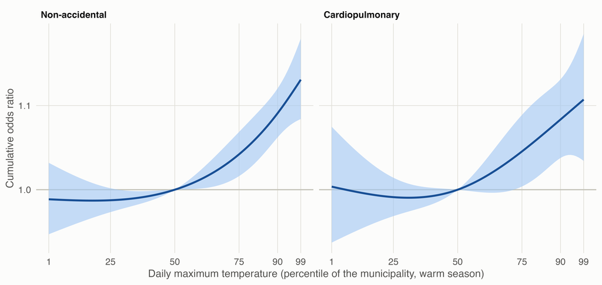

Figure 6: Cumulative odds ratio of death over lags 0 to 3 along the temperature scale, relative to the 50th percentile. Bands are 95% confidence intervals.

```r
c1 <- curve[model == "temperature"]
c1[, cause := factor(cause_labels[outcome], levels = cause_labels[unique(outcome)])]
ggplot(c1, aes(percentile, or)) +
  geom_hline(yintercept = 1, colour = ink$axis) +
  geom_ribbon(aes(ymin = or_low, ymax = or_high), fill = ramp_blue[2], alpha = 0.6) +
  geom_line(colour = ramp_blue[6], linewidth = 0.9) +
  facet_wrap(~cause) +
  scale_x_continuous(breaks = c(1, 25, 50, 75, 90, 99)) +
  labs(x = "Daily maximum temperature (percentile of the municipality, warm season)",
       y = "Cumulative odds ratio")
```

```r
t3 <- temperature_or[model == "temperature"]
t3[, `:=`(cause = cause_labels[outcome], lag = lag_factor(lag), value = ci(or, or_low, or_high))]
kable(dcast(t3, cause + lag ~ paste0("P", percentile), value.var = "value"),
      col.names = c("Cause", "Lag", paste0("P", sort(unique(t3$percentile)))))
```

Table 12: Odds ratios (95% confidence interval) of temperature percentiles against the 50th percentile, by lag and cumulative.

| Cause | Lag | P90 | P95 | P99 |
| --- | --- | --- | --- | --- |
| Cardiopulmonary | 0 | 1.021 (0.990 to 1.053) | 1.021 (0.984 to 1.060) | 1.022 (0.975 to 1.071) |
| Cardiopulmonary | 1 | 1.032 (0.999 to 1.067) | 1.036 (0.994 to 1.080) | 1.039 (0.987 to 1.095) |
| Cardiopulmonary | 2 | 1.016 (0.982 to 1.050) | 1.031 (0.989 to 1.074) | 1.045 (0.992 to 1.100) |
| Cardiopulmonary | 3 | 1.012 (0.982 to 1.044) | 1.005 (0.968 to 1.043) | 0.998 (0.952 to 1.047) |
| Cardiopulmonary | Cumulative | 1.083 (1.038 to 1.131) | 1.097 (1.041 to 1.155) | 1.107 (1.034 to 1.185) |
| Non-accidental | 0 | 1.030 (1.011 to 1.050) | 1.040 (1.017 to 1.065) | 1.049 (1.019 to 1.080) |
| Non-accidental | 1 | 1.036 (1.015 to 1.058) | 1.044 (1.017 to 1.071) | 1.050 (1.017 to 1.084) |
| Non-accidental | 2 | 1.008 (0.987 to 1.029) | 1.014 (0.988 to 1.040) | 1.019 (0.987 to 1.052) |
| Non-accidental | 3 | 1.014 (0.995 to 1.034) | 1.011 (0.988 to 1.035) | 1.007 (0.978 to 1.037) |
| Non-accidental | Cumulative | 1.091 (1.062 to 1.120) | 1.112 (1.077 to 1.149) | 1.131 (1.084 to 1.180) |

```r
cumulative <- temperature_or[model == "temperature" & lag == "cumulative" & outcome == "non_accidental"]
cum <- function(p) cumulative[percentile == p, ci(or, or_low, or_high)]
low_side <- curve[model == "temperature" & outcome == "non_accidental" & percentile < temperature$reference]
```

Below the median the curve is flat: the cumulative odds ratio stays between 0.987 and 0.999. Above it the odds of death rise with temperature, to 1.091 (1.062 to 1.120) at the 90th percentile, 1.112 (1.077 to 1.149) at the 95th and 1.131 (1.084 to 1.180) at the 99th for non-accidental mortality. As with the categories, the association is in lags 0 and 1.

## 2.4 Ozone as a continuous exposure

Ozone per 10 ppb of the delivered 24-hour mean, with one coefficient per lag, alone and in the same model as the temperature cross-basis.

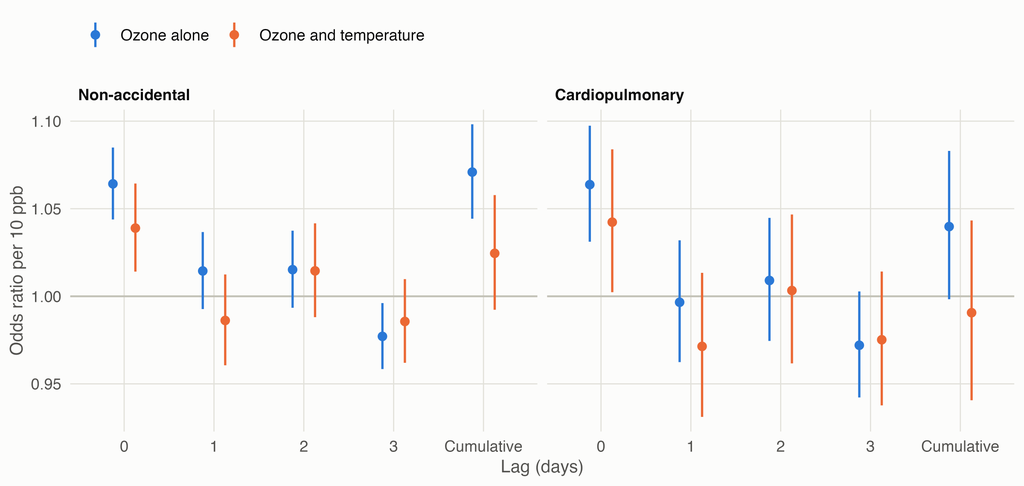

Figure 7: Odds ratio of death per 10 ppb of ozone by lag and cumulative, without and with temperature in the model. Bars are 95% confidence intervals.

```r
o1 <- copy(ozone_or)
colour_adjust <- c("Ozone alone" = "#2a78d6", "Ozone and temperature" = "#eb6834")
o1[, `:=`(cause = factor(cause_labels[outcome], levels = cause_labels[unique(outcome)]),
          lag = lag_factor(lag),
          model = factor(fifelse(model == "ozone", "Ozone alone", "Ozone and temperature"),
                         levels = names(colour_adjust)))]
ggplot(o1, aes(lag, or, colour = model)) +
  geom_hline(yintercept = 1, colour = ink$axis) +
  geom_pointrange(aes(ymin = or_low, ymax = or_high), position = position_dodge(width = 0.5),
                  linewidth = 0.6, size = 0.3) +
  facet_wrap(~cause) +
  scale_colour_manual(values = colour_adjust) +
  labs(x = "Lag (days)", y = sprintf("Odds ratio per %d ppb", ozone_increment), colour = NULL)
```

```r
o1[, value := ci(or, or_low, or_high)]
kable(dcast(o1, cause + lag ~ model, value.var = "value"),
      col.names = c("Cause", "Lag", levels(o1$model)))
```

Table 13: Odds ratio per 10 ppb of ozone (95% confidence interval).

| Cause | Lag | Ozone alone | Ozone and temperature |
| --- | --- | --- | --- |
| Non-accidental | 0 | 1.064 (1.044 to 1.085) | 1.039 (1.014 to 1.064) |
| Non-accidental | 1 | 1.014 (0.993 to 1.037) | 0.986 (0.961 to 1.012) |
| Non-accidental | 2 | 1.015 (0.993 to 1.037) | 1.015 (0.988 to 1.042) |
| Non-accidental | 3 | 0.977 (0.958 to 0.996) | 0.986 (0.962 to 1.010) |
| Non-accidental | Cumulative | 1.071 (1.044 to 1.098) | 1.025 (0.992 to 1.058) |
| Cardiopulmonary | 0 | 1.064 (1.031 to 1.097) | 1.042 (1.002 to 1.084) |
| Cardiopulmonary | 1 | 0.997 (0.962 to 1.032) | 0.971 (0.931 to 1.013) |
| Cardiopulmonary | 2 | 1.009 (0.975 to 1.045) | 1.003 (0.962 to 1.047) |
| Cardiopulmonary | 3 | 0.972 (0.942 to 1.003) | 0.975 (0.938 to 1.014) |
| Cardiopulmonary | Cumulative | 1.040 (0.998 to 1.083) | 0.991 (0.941 to 1.043) |

```r
oz_cum <- function(outcome_value, model_value) {
  ozone_or[outcome == outcome_value & model == model_value & lag == "cumulative",
           ci(or, or_low, or_high)]
}
temp_with_ozone <- temperature_or[model == "temperature + ozone" & lag == "cumulative" &
                                    outcome == "non_accidental" & percentile == 95,
                                  ci(or, or_low, or_high)]
```

The cumulative odds ratio per 10 ppb for non-accidental mortality goes from 1.071 (1.044 to 1.098) to 1.025 (0.992 to 1.058) when temperature is in the model, and for cardiopulmonary mortality from 1.040 (0.998 to 1.083) to 0.991 (0.941 to 1.043). Most of the association of the 24-hour ozone mean with mortality is shared with temperature. The reverse does not happen: with ozone in the model the cumulative odds ratio of the 95th temperature percentile is 1.102 (1.065 to 1.141), against 1.112 (1.077 to 1.149) without it.

## 2.5 What this adds

1. The associations with heatwaves and high ozone are on the day of exposure and the day after. Lags 2 and 3 taken alone mix them with the exposure of the days before.
2. With the working definitions the additive interaction is null at every lag, and over the window its interval includes zero.
3. Over the four-day window the REOI is positive in most combinations of definitions, and its interval excludes zero for those with the most heatwave days, with or without temperature in the model. It is exploratory and needs a primary definition and lag window fixed in advance.
4. Temperature has a clear association with mortality above the median of the warm season, rising up to the hottest days.
5. The association of the 24-hour ozone mean is largely shared with temperature. This bears on the secondary aim of the plan, the mediation of the heat effect by ozone, which has not been analysed here: an ozone association this small once temperature is accounted for leaves little room for a large mediated share.

These readings rest on the delivered 24-hour ozone series. The validation of the ozone exposure shows that it follows the hourly records less well on the days with most ozone; the same models can be run on the rebuilt series by changing `ozone_series_main` in the configuration.

## 2.6 Method checks

*Script: `tests/test_methods.R`, run here and at the start of every run of `Code/run_all.R`.*

**Run tests/test_methods.R**

```r
checks <- system2(file.path(R.home("bin"), "Rscript"),
                  shQuote(here::here("tests", "test_methods.R")), stdout = TRUE, stderr = TRUE)
if (!is.null(attr(checks, "status"))) stop(paste(checks, collapse = "\n"))
cat(grep("distributed lags|dlnm|cumulative|all lags|combine_coefficients|local_percentile|^All",
         checks, value = TRUE), sep = "\n")
```

```
ok   local_percentile: share of the reference values of the same municipality at or below
ok   combine_coefficients: sum of two coefficients and its standard error
     all lags together: 1.131, 1.099, 1.004, 0.989  truth: 1.150, 1.080, 1.000, 1.000;  lag 2 alone: 1.068
ok   distributed lags: the model with all the lags recovers the true lag structure
ok   distributed lags: the single-lag model at lag 2 picks up the earlier lags
ok   distributed lags: the cumulative interval covers the true cumulative odds ratio
     cumulative odds ratio at P90 and P99 against P50: dlnm 1.2563, 1.3416  by hand 1.2563, 1.3416  truth 1.2712, 1.3418
ok   dlnm cross-basis and the hand-built spline give the same cumulative odds ratios
ok   the cumulative interval at P90 covers the true value
All checks passed.
```

The checks simulate deaths with an effect at lags 0 and 1 only: the model with all the lags recovers it, and the single-lag model at lag 2 reports an association that is not there. They also confirm that the cross-basis of `dlnm` and a spline built by hand for each lag give the same cumulative odds ratios.

# 3 Publication figures

*Script: `Code/50_figures_publication.R`. Figures: the files `figure_*` of `Output/Figures`, each as PDF and as PNG.*

`Code/50_figures_publication.R` draws the figures from the saved tables, as PDF and as PNG at 600 dpi, in `Output/Figures`. The button under each figure saves the PNG file; the PDF files are in [`Output/Figures`](https://github.com/AmaruSimonAgueroJimenez/Heatwave-ozone-mortality-Chile/tree/main/Output/Figures) of the repository.

```r
figure_content <- c(
  figure_1_odds_ratios_by_lag = "Odds ratios of the exposure categories by lag",
  figure_2_reoi_by_cause = "Forest plot of the REOI by cause of death",
  figure_3_interaction_matrix = "REOI across heatwave definitions and ozone cut-offs, non-accidental",
  figure_4_subgroups = "Age groups and sex",
  figure_5_attributable_deaths = "Excess deaths by year and by municipality",
  figure_6_lag_structure = "Single-lag and distributed-lag estimates",
  figure_7_adjustment = "Multi-pollutant adjustment",
  figure_s1_interaction_matrix_cardiopulmonary = "REOI across definitions, cardiopulmonary",
  figure_s2_interaction_matrix_all_lags = "REOI across definitions, all the lags in one model",
  figure_s3_interaction_matrix_all_lags_temperature = "The same, with temperature in the model"
)
# Every figure the script wrote is in the list, and every figure of the list was written
written <- sub("\\.pdf$", "", sort(list.files(dir_figures, pattern = "^figure_.*\\.pdf$")))
stopifnot(setequal(written, names(figure_content)),
          file.exists(file.path(dir_figures, paste0(names(figure_content), ".png"))))
kable(data.table(file = sprintf("`%s.pdf` and `.png`", names(figure_content)), content = unname(figure_content)),
      col.names = c("File", "Content"))
```

Table 14: Files written by the figures script.

| File | Content |
| --- | --- |
| `figure_1_odds_ratios_by_lag.pdf` and `.png` | Odds ratios of the exposure categories by lag |
| `figure_2_reoi_by_cause.pdf` and `.png` | Forest plot of the REOI by cause of death |
| `figure_3_interaction_matrix.pdf` and `.png` | REOI across heatwave definitions and ozone cut-offs, non-accidental |
| `figure_4_subgroups.pdf` and `.png` | Age groups and sex |
| `figure_5_attributable_deaths.pdf` and `.png` | Excess deaths by year and by municipality |
| `figure_6_lag_structure.pdf` and `.png` | Single-lag and distributed-lag estimates |
| `figure_7_adjustment.pdf` and `.png` | Multi-pollutant adjustment |
| `figure_s1_interaction_matrix_cardiopulmonary.pdf` and `.png` | REOI across definitions, cardiopulmonary |
| `figure_s2_interaction_matrix_all_lags.pdf` and `.png` | REOI across definitions, all the lags in one model |
| `figure_s3_interaction_matrix_all_lags_temperature.pdf` and `.png` | The same, with temperature in the model |

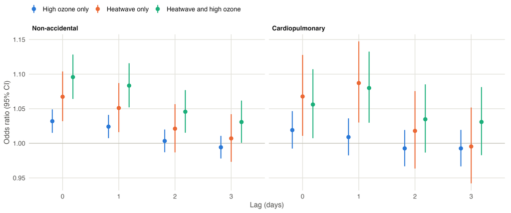

Figure 8: Odds ratios of the exposure categories by lag. File `figure_1_odds_ratios_by_lag.png`.

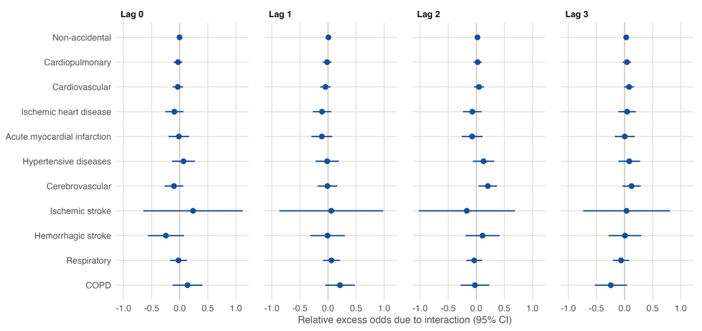

Figure 9: Forest plot of the REOI by cause of death. File `figure_2_reoi_by_cause.png`.

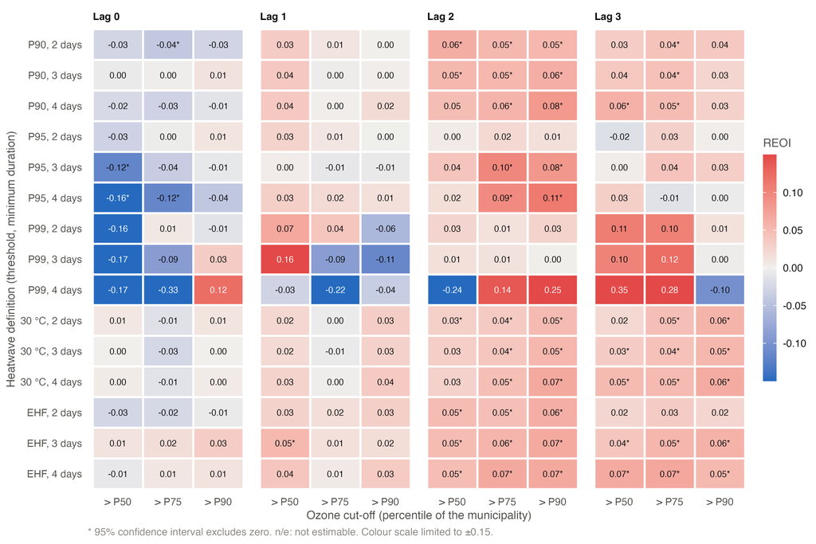

Figure 10: REOI across heatwave definitions and ozone cut-offs, non-accidental. File `figure_3_interaction_matrix.png`.

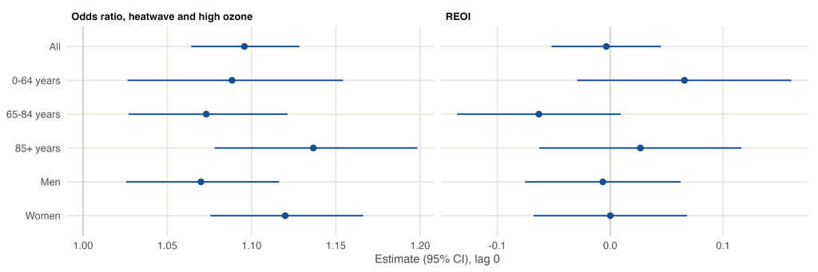

Figure 11: Age groups and sex. File `figure_4_subgroups.png`.

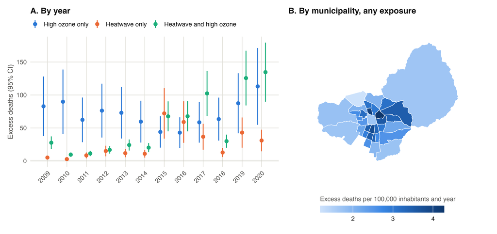

Figure 12: Excess deaths by year and by municipality. File `figure_5_attributable_deaths.png`.

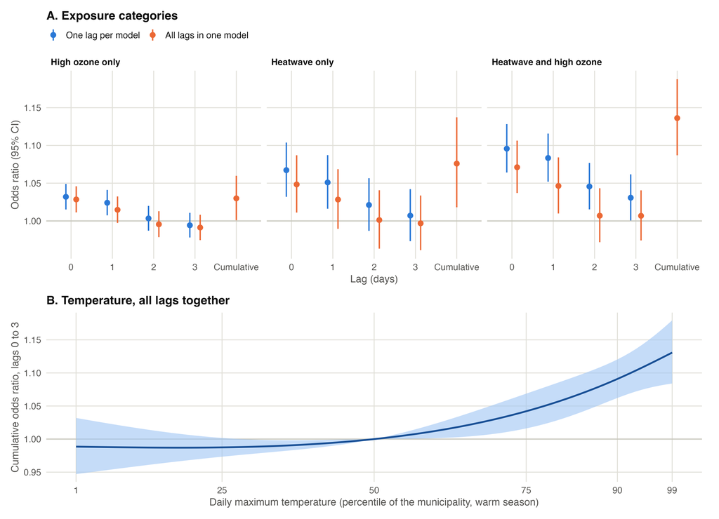

Figure 13: Single-lag and distributed-lag estimates. File `figure_6_lag_structure.png`.

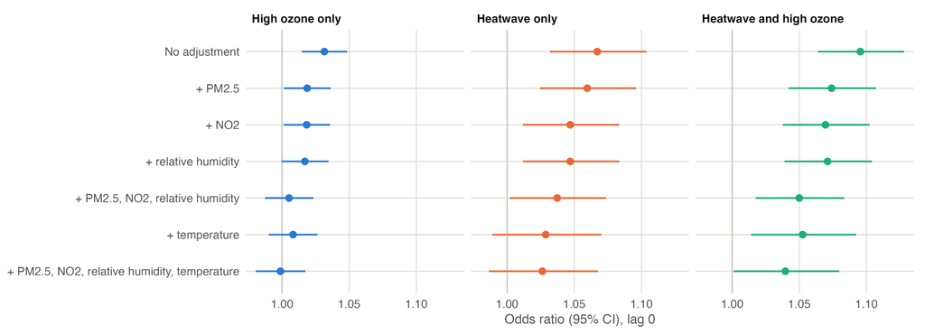

Figure 14: Multi-pollutant adjustment. File `figure_7_adjustment.png`.

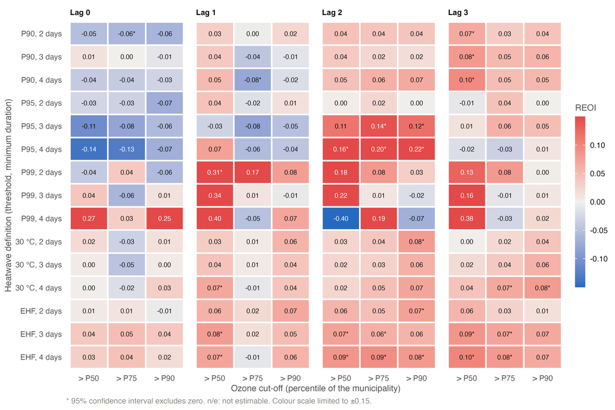

Figure 15: REOI across definitions, cardiopulmonary. File `figure_s1_interaction_matrix_cardiopulmonary.png`.

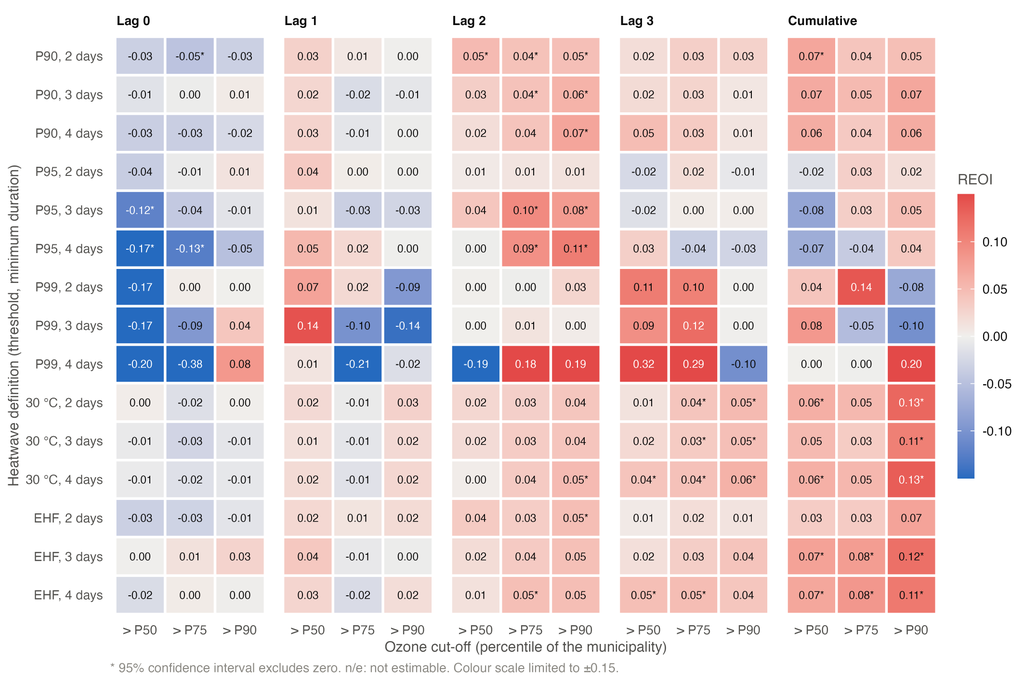

Figure 16: REOI across definitions, all the lags in one model. File `figure_s2_interaction_matrix_all_lags.png`.

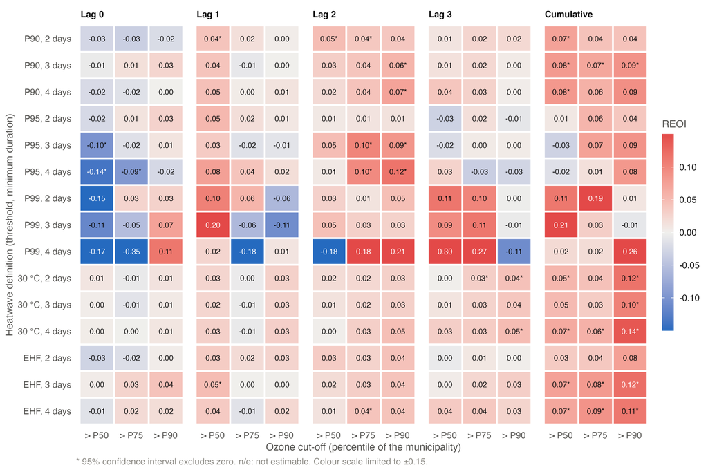

Figure 17: The same, with temperature in the model. File `figure_s3_interaction_matrix_all_lags_temperature.png`.

```r
knitr::include_graphics(file.path(dir_figures, paste0(names(figure_content), ".png")))
```

# 4 R scripts

The scripts are in [`Code/`](https://github.com/AmaruSimonAgueroJimenez/Heatwave-ozone-mortality-Chile/tree/main/Code) of the repository. They are not executed when this page is rendered: `Code/run_all.R` runs them in order and this page reads their outputs. The code of each one is folded below.

| Script | Purpose |
| --- | --- |
| `Code/40_sensitivity_analyses.R` | Adjustment for PM2.5, NO2, humidity and temperature; three ozone levels; alternative ozone series. |
| `Code/41_distributed_lag_models.R` | All the lags in one model: exposure categories (also over the grid of definitions), temperature (dlnm) and ozone. |
| `Code/50_figures_publication.R` | Publication figures in PDF and PNG, drawn from the result tables. |

**Code/40_sensitivity_analyses.R**

```r
# 40_sensitivity_analyses.R
# Sensitivity analyses of the compound model (headline definitions).
#
# Inputs
#   Data/Derived/case_crossover.csv, exposure_lagged.csv   (script 21)
#   Data/Derived/exposure_2009_2020.csv                    (script 13)
#   Data/Derived/exposure_air_pollution_all.csv            (script 11)
#   Output/Tables/models_grid.csv                          (script 30)
# Outputs
#   Output/Tables/sensitivity_adjustment_or.csv            odds ratios by adjustment
#   Output/Tables/sensitivity_adjustment_interaction.csv   REOI, AP, S by adjustment
#   Output/Tables/sensitivity_reference_or.csv             three ozone levels
#   Output/Tables/sensitivity_reference_interaction.csv
#   Output/Tables/sensitivity_ozone_series.csv             alternative ozone series
#
# 1. Multi-pollutant adjustment. The compound model is refitted with PM2.5,
#    nitrogen dioxide and relative humidity as continuous covariates at the
#    same lag as the exposure, one at a time and together, and (not in the
#    plan) with the temperature of the same day. Every variant uses the same
#    deaths: those whose referent days have all the covariates.
# 2. Reference category. Three ozone levels (low, medium, high) instead of two,
#    so that the reference is "no heatwave and low ozone" as worded in the plan.
# 3. Ozone series. The same model with each ozone series of the exposure
#    dataset and with the version "all" of the delivered series.
#
# One element changes at a time; everything else is the headline model of
# script 30, built with the same functions (Code/01_functions.R).

suppressPackageStartupMessages(library(survival))
source(here::here("Code", "00_setup.R"))
source(here::here("Code", "01_functions.R"))

conf_level <- get_param("models", "conf_level")
lags <- unlist(get_param("design", "lags_days"))
outcomes <- unlist(get_param("sensitivity", "outcomes"))
heatwave_main <- get_param("models", "heatwave_main")
series_main <- get_param("air_pollution", "ozone_series_main")
method_main <- get_param("air_pollution", "interpolation_method_main")
cutoff_main <- get_param("models", "ozone_cutoff_main")
cutoffs <- unlist(get_param("air_pollution", "ozone_percentile_cutoffs"))
ozone_flag_main <- paste0(series_main, "_", method_main, "_gt_p", cutoff_main)
age_labels <- unlist(get_param("mortality", "age_labels"))
increments <- get_param("sensitivity", "adjustment_increments")
adjust_for_temperature <- get_param("sensitivity", "adjust_for_temperature")
low_cutoff <- get_param("sensitivity", "low_ozone_cutoff")
temperature <- get_param("temperature_response")
stopifnot(identical(temperature$scale, "local_percentile"), low_cutoff < cutoff_main,
          low_cutoff %in% cutoffs)

cc <- fread(derived_path("case_crossover.csv"), encoding = "UTF-8")
cc[, `:=`(date = as.Date(date), case_date = as.Date(case_date))]
lagged <- fread(derived_path("exposure_lagged.csv"), encoding = "UTF-8")
lagged[, date := as.Date(date)]
exposure <- fread(derived_path("exposure_2009_2020.csv"), encoding = "UTF-8")
exposure[, date := as.Date(date)]
warm_study <- exposure[in_study_period == TRUE & warm_season == TRUE]

# Temperature of each lagged day as a percentile of the warm-season days of
# its municipality
temperature_reference <- warm_study[, .(com, value = get(temperature$variable))]
for (lag in lags) {
  lagged[, (paste0("tpct_lag", lag)) := local_percentile(
    get(paste0(temperature$variable, "_lag", lag)), com, temperature_reference
  )]
}

model_data <- lapply(setNames(outcomes, outcomes), function(outcome) {
  prepare_model_data(cc, lagged, outcome, "all", age_labels)
})

# ---- 1. Multi-pollutant adjustment -------------------------------------------

covariates <- names(increments)
adjustments <- list("none" = character(0))
for (v in covariates) adjustments[[v]] <- v
adjustments[[paste(covariates, collapse = " + ")]] <- covariates
if (adjust_for_temperature) {
  adjustments[["temperature"]] <- "temperature"
  adjustments[[paste(c(covariates, "temperature"), collapse = " + ")]] <- c(covariates, "temperature")
}
spline_at <- function(percentiles) {
  spline_basis(percentiles, temperature$spline_knots, temperature$spline_boundary, "temp_s")
}

run_adjustment <- function(outcome, lag) {
  d <- attach_compound_exposure(model_data[[outcome]], lagged, heatwave_main, ozone_flag_main, lag)
  for (v in covariates) {
    d[, (v) := lagged[[paste0(v, "_", method_main, "_lag", lag)]][exposure_row] / increments[[v]]]
  }
  basis <- spline_at(lagged[[paste0("tpct_lag", lag)]][d$exposure_row])
  temperature_terms <- colnames(basis)
  d[, (temperature_terms) := as.data.table(basis)]
  # The same deaths in every variant: strata complete in all the covariates
  complete <- stats::complete.cases(d[, c(covariates, temperature_terms), with = FALSE])
  keep <- d[, .(ok = all(complete[.I])), by = stratum][ok == TRUE, stratum]
  deaths_before <- d[case == 1, sum(n_deaths)]
  d <- d[stratum %in% keep]
  label <- data.table(outcome = outcome, lag = lag, deaths = d[case == 1, sum(n_deaths)],
                      deaths_dropped = deaths_before - d[case == 1, sum(n_deaths)])
  or_rows <- list()
  interaction_rows <- list()
  for (name in names(adjustments)) {
    keys <- adjustments[[name]]
    terms <- c(setdiff(keys, "temperature"), if ("temperature" %in% keys) temperature_terms)
    logged <- with_warnings(compound_results(d, conf_level, adjust = terms))
    result <- logged$value
    stopifnot(result$fit$n_deaths == label$deaths)
    or <- result$or[!term %in% temperature_terms]
    if ("temperature" %in% keys) {
      # Odds ratio of a day at each contrast percentile against the reference
      weights <- sweep(spline_at(temperature$contrasts), 2, spline_at(temperature$reference)[1, ])
      contrast <- combine_coefficients(result$fit, weights, conf_level)
      contrast[, `:=`(term = paste0("temperature_p", temperature$contrasts),
                      p_value = 2 * stats::pnorm(-abs(log_or / se)))]
      or <- rbind(or, contrast, use.names = TRUE)
    }
    fit_warnings <- paste(unique(logged$warnings), collapse = " | ")
    or_rows[[name]] <- cbind(label, adjustment = name, or, fit_warnings = fit_warnings)
    interaction_rows[[name]] <- cbind(label, adjustment = name, result$interaction,
                                      fit_warnings = fit_warnings)
  }
  list(or = rbindlist(or_rows), interaction = rbindlist(interaction_rows))
}
jobs <- CJ(outcome = outcomes, lag = lags, sorted = FALSE)
adjusted <- lapply(seq_len(nrow(jobs)), function(i) run_adjustment(jobs$outcome[i], jobs$lag[i]))
adjustment_or <- rbindlist(lapply(adjusted, `[[`, "or"))
adjustment_or[, increment := vapply(term, function(x) {
  if (x %in% covariates) as.numeric(increments[[x]]) else NA_real_
}, numeric(1))]
fwrite(adjustment_or, file.path(dir_tables, "sensitivity_adjustment_or.csv"))
fwrite(rbindlist(lapply(adjusted, `[[`, "interaction")),
       file.path(dir_tables, "sensitivity_adjustment_interaction.csv"))
```

```r
# ---- 2. Reference category: three ozone levels --------------------------------

high_flag <- ozone_flag_main
low_flag <- paste0(series_main, "_", method_main, "_gt_p", low_cutoff)
level_terms <- c("h0_medium", "h0_high", "h1_low", "h1_medium", "h1_high")

run_reference <- function(outcome, lag) {
  d <- copy(model_data[[outcome]])
  d[, hw := lagged[[paste0(heatwave_main, "_lag", lag)]][exposure_row]]
  d[, above_high := lagged[[paste0(high_flag, "_lag", lag)]][exposure_row]]
  d[, above_low := lagged[[paste0(low_flag, "_lag", lag)]][exposure_row]]
  complete <- d[, .(ok = !anyNA(hw) && !anyNA(above_high) && !anyNA(above_low)),
                by = stratum][ok == TRUE, stratum]
  d <- d[stratum %in% complete]
  stopifnot(d[, all(above_low >= above_high)])
  d[, level := fifelse(above_high == 1, "high", fifelse(above_low == 1, "medium", "low"))]
  for (term in level_terms) {
    parts <- strsplit(term, "_", fixed = TRUE)[[1]]
    d[, (term) := as.integer(hw == as.integer(sub("h", "", parts[1])) & level == parts[2])]
  }
  counts <- d[case == 1, .(deaths = sum(n_deaths)), by = .(hw, level)]
  logged <- with_warnings(fit_conditional_logit(d, level_terms))
  fit <- logged$value
  or <- odds_ratios(fit, conf_level)
  or[, c("heatwave", "ozone_level") := tstrsplit(sub("^h", "", term), "_", fixed = TRUE)]
  or <- merge(or, counts[, .(heatwave = as.character(hw), ozone_level = level, deaths)],
              by = c("heatwave", "ozone_level"))
  reference_deaths <- counts[hw == 0 & level == "low", deaths]
  measures <- rbindlist(lapply(c("high", "medium"), function(level_value) {
    use <- c("h1_low", paste0("h0_", level_value), paste0("h1_", level_value))
    cbind(contrast = paste(level_value, "against low ozone"),
          additive_interaction(coef(fit)[use], vcov(fit)[use, use], conf_level))
  }))
  label <- data.table(outcome = outcome, lag = lag, deaths_total = fit$n_deaths,
                      deaths_reference = reference_deaths,
                      fit_warnings = paste(unique(logged$warnings), collapse = " | "))
  list(or = cbind(label, or), interaction = cbind(label, measures))
}
reference <- lapply(seq_len(nrow(jobs)), function(i) run_reference(jobs$outcome[i], jobs$lag[i]))
fwrite(rbindlist(lapply(reference, `[[`, "or")),
       file.path(dir_tables, "sensitivity_reference_or.csv"))
fwrite(rbindlist(lapply(reference, `[[`, "interaction")),
       file.path(dir_tables, "sensitivity_reference_interaction.csv"))

# ---- 3. Ozone series ----------------------------------------------------------

# Flag of the days above a percentile of the warm-season days of the study
# years in each municipality: the rule of script 13.
flag_above <- function(table, series, percentile) {
  cut <- table[in_study_period == TRUE & warm_season == TRUE & !is.na(get(series)),
               .(cut = stats::quantile(get(series), percentile / 100, type = 7, names = FALSE)),
               by = com]
  as.integer(table[[series]] > cut$cut[match(table$com, cut$com)])
}
# The rule reproduces the flags of the exposure dataset
for (series in c(paste0(series_main, "_idw"), paste0(series_main, "_ok"))) {
  stopifnot(identical(flag_above(exposure, series, cutoff_main),
                      exposure[[paste0(series, "_gt_p", cutoff_main)]]))
}

# Version "all" of the delivered series, flagged and lagged in the same way
version_all <- fread(derived_path("exposure_air_pollution_all.csv"), encoding = "UTF-8",
                     select = c("com", "date", "o3_idw", "o3_ok"))
version_all[, date := as.Date(date)]
setnames(version_all, c("o3_idw", "o3_ok"), c("o3all_idw", "o3all_ok"))
version_all <- merge(version_all, exposure[, .(com, date, in_study_period, warm_season)],
                     by = c("com", "date"))
stopifnot(nrow(version_all) == nrow(exposure))
all_flags <- paste0(c("o3all_idw", "o3all_ok"), "_gt_p", cutoff_main)
for (series in c("o3all_idw", "o3all_ok")) {
  version_all[, (paste0(series, "_gt_p", cutoff_main)) := flag_above(version_all, series, cutoff_main)]
}
all_lagged <- lagged_exposure(version_all[, c("com", "date", all_flags), with = FALSE], all_flags, lags)
lagged <- merge(lagged, all_lagged, by = c("com", "date"), all.x = TRUE, sort = FALSE)
# The merge keeps the rows; the positions stored in the model datasets must
# still point at the same municipality-day
model_data <- lapply(setNames(outcomes, outcomes), function(outcome) {
  prepare_model_data(cc, lagged, outcome, "all", age_labels)
})

series_labels <- c(
  o3_idw = "Delivered, operational period, IDW", o3_ok = "Delivered, operational period, kriging",
  o3all_idw = "Delivered, all values, IDW", o3all_ok = "Delivered, all values, kriging",
  o3obs_idw = "Rebuilt 24-hour mean, IDW", o3obs_ok = "Rebuilt 24-hour mean, kriging",
  o3mda8_idw = "Rebuilt MDA8, IDW", o3mda8_ok = "Rebuilt MDA8, kriging"
)
series_jobs <- CJ(outcome = outcomes, series = names(series_labels), lag = lags, sorted = FALSE)
series_results <- rbindlist(lapply(seq_len(nrow(series_jobs)), function(i) {
  job <- series_jobs[i]
  flag <- paste0(job$series, "_gt_p", cutoff_main)
  d <- attach_compound_exposure(model_data[[job$outcome]], lagged, heatwave_main, flag, job$lag)
  logged <- with_warnings(compound_results(d, conf_level))
  or <- dcast(logged$value$or[, .(term, or, or_low, or_high)], . ~ term,
              value.var = c("or", "or_low", "or_high"))[, !"."]
  measures <- dcast(logged$value$interaction[, .(measure = gsub(" ", "_", tolower(measure)),
                                                 estimate, low, high)],
                    . ~ measure, value.var = c("estimate", "low", "high"))[, !"."]
  cbind(job, series_label = series_labels[[job$series]], ozone = flag, category_deaths(d),
        or, measures, fit_warnings = paste(unique(logged$warnings), collapse = " | "))
}))
# The series already in the definition grid of script 30 give the same numbers
grid <- fread(file.path(dir_tables, "models_grid.csv"))
both <- merge(series_results, grid[heatwave == heatwave_main],
              by = c("outcome", "ozone", "lag"), suffixes = c("", "_grid"))
stopifnot(nrow(both) == length(outcomes) * 6 * length(lags),
          max(abs(both$estimate_reoi - both$estimate_reoi_grid)) < 1e-8,
          max(abs(both$or_e11 - both$or_e11_grid)) < 1e-8)
fwrite(series_results, file.path(dir_tables, "sensitivity_ozone_series.csv"))
```

```r
message("Sensitivity analyses written: ", nrow(adjustment_or), " adjusted odds ratios, ",
        nrow(series_results), " ozone-series fits")
print(adjustment_or[outcome == outcomes[1] & lag == get_param("models", "lag_main") &
                      term %in% c("e10", "e01", "e11"),
                    .(adjustment, term, deaths, or = round(or, 3), or_low = round(or_low, 3),
                      or_high = round(or_high, 3))])
```

**Code/41_distributed_lag_models.R**

```r
# 41_distributed_lag_models.R
# Lag structure of the associations: all the lags in the same model.
#
# Inputs
#   Data/Derived/case_crossover.csv, exposure_lagged.csv   (script 21)
#   Data/Derived/exposure_2009_2020.csv                    (script 13)
# Outputs
#   Output/Tables/lags_compound_or.csv            E10, E01, E11 by lag and cumulative
#   Output/Tables/lags_compound_interaction.csv   REOI, AP, S of the cumulative odds ratios
#   Output/Tables/lags_grid.csv                   the same over the grid of definitions
#   Output/Tables/lags_temperature_or.csv         temperature contrasts by lag and cumulative
#   Output/Tables/lags_temperature_curve.csv      cumulative odds ratio along the temperature scale
#   Output/Tables/lags_ozone_or.csv               ozone per increment, by lag and cumulative
#
# The models of script 30 take one lag at a time. Exposures of consecutive
# days are correlated (a heatwave lasts at least two days by definition), so
# the odds ratio of one lag also carries the effect of its neighbours. Here
# the exposures of all the lags of design$lags_days enter together, with one
# coefficient per lag (unconstrained lag structure):
#
# 1. Compound exposure. Indicators of E10, E01 and E11 at every lag. The
#    cumulative odds ratio of a category is the product of its odds ratios
#    over the lags: the odds of death after being in that category on every
#    day of the window against being in E00 on every day. The additive
#    interaction is computed from the cumulative odds ratios, and also at
#    each lag from the three coefficients of that lag. The model is fitted
#    for the headline definitions and for every heatwave definition and ozone
#    cut-off of the headline ozone series. Over that grid it is fitted a
#    second time with the temperature of every lag in the model (the spline
#    of point 2), to see whether an interaction between the two indicators
#    is temperature that the heatwave threshold leaves out.
# 2. Temperature. Distributed lag non-linear model (package dlnm): natural
#    cubic spline of the temperature percentile (temperature_response) crossed
#    with the lags. Odds ratios of the contrast percentiles against the
#    reference percentile, by lag and cumulative.
# 3. Ozone. Linear term per increment at every lag, alone and together with
#    the temperature cross-basis.

suppressPackageStartupMessages({
  library(survival)
  library(dlnm)
})
source(here::here("Code", "00_setup.R"))
source(here::here("Code", "01_functions.R"))

conf_level <- get_param("models", "conf_level")
lags <- unlist(get_param("design", "lags_days"))
stopifnot(identical(as.integer(lags), 0:max(lags)))   # consecutive lags from 0
outcomes <- unlist(get_param("distributed_lags", "outcomes"))
ozone_increment <- get_param("distributed_lags", "ozone_increment_ppb")
heatwave_main <- get_param("models", "heatwave_main")
ozone_series <- paste0(get_param("air_pollution", "ozone_series_main"), "_",
                       get_param("air_pollution", "interpolation_method_main"))
ozone_flag_main <- paste0(ozone_series, "_gt_p", get_param("models", "ozone_cutoff_main"))
age_labels <- unlist(get_param("mortality", "age_labels"))
temperature <- get_param("temperature_response")
stopifnot(identical(temperature$scale, "local_percentile"))
categories <- c("e10", "e01", "e11")

cc <- fread(derived_path("case_crossover.csv"), encoding = "UTF-8")
cc[, `:=`(date = as.Date(date), case_date = as.Date(case_date))]
lagged <- fread(derived_path("exposure_lagged.csv"), encoding = "UTF-8")
lagged[, date := as.Date(date)]
exposure <- fread(derived_path("exposure_2009_2020.csv"), encoding = "UTF-8",
                  select = c("com", "date", "in_study_period", "warm_season", temperature$variable))
temperature_reference <- exposure[in_study_period == TRUE & warm_season == TRUE,
                                  .(com, value = get(temperature$variable))]
for (lag in lags) {
  lagged[, (paste0("tpct_lag", lag)) := local_percentile(
    get(paste0(temperature$variable, "_lag", lag)), com, temperature_reference
  )]
}
# One spline basis of the temperature percentile per lag
temperature_terms <- character(0)
for (lag in lags) {
  basis <- spline_basis(lagged[[paste0("tpct_lag", lag)]], temperature$spline_knots,
                        temperature$spline_boundary, paste0("temp_lag", lag, "_s"))
  lagged[, (colnames(basis)) := as.data.table(basis)]
  temperature_terms <- c(temperature_terms, colnames(basis))
}
model_data <- lapply(setNames(outcomes, outcomes), function(outcome) {
  prepare_model_data(cc, lagged, outcome, "all", age_labels)
})

# ---- 1. Compound exposure, all lags together ----------------------------------

compound_terms <- as.vector(t(outer(categories, lags, paste, sep = "_lag")))
# Weights that add the coefficients of each category over the lags
cumulative_weights <- t(sapply(categories, function(category) {
  as.numeric(sub("_lag.*", "", compound_terms) == category)
}))
colnames(cumulative_weights) <- compound_terms

# Odds ratios and REOI of one heatwave definition and one ozone flag, by lag
# and cumulative, from the model with all the lags. With `adjust_temperature`
# the temperature splines of all the lags are added to the model.
fit_compound_lags <- function(outcome, heatwave, ozone_flag, adjust_temperature = FALSE) {
  d <- copy(model_data[[outcome]])
  if (adjust_temperature) {
    d[, (temperature_terms) := lagged[exposure_row, temperature_terms, with = FALSE]]
  }
  adjust <- if (adjust_temperature) temperature_terms else character(0)
  for (lag in lags) {
    hw <- lagged[[paste0(heatwave, "_lag", lag)]][d$exposure_row]
    oz <- lagged[[paste0(ozone_flag, "_lag", lag)]][d$exposure_row]
    d[, (paste0("e10_lag", lag)) := as.integer(hw == 1 & oz == 0)]
    d[, (paste0("e01_lag", lag)) := as.integer(hw == 0 & oz == 1)]
    d[, (paste0("e11_lag", lag)) := as.integer(hw == 1 & oz == 1)]
  }
  # Every term needs deaths with and without it on the day of death
  case_days <- d[case == 1 & stats::complete.cases(d[, compound_terms, with = FALSE])]
  deaths_exposed <- vapply(compound_terms, function(term) case_days[get(term) == 1, sum(n_deaths)],
                           numeric(1))
  label <- data.table(outcome = outcome, heatwave = heatwave, ozone = ozone_flag,
                      adjustment = if (adjust_temperature) "temperature" else "none",
                      deaths = case_days[, sum(n_deaths)], smallest_cell = min(deaths_exposed))
  if (min(deaths_exposed) == 0) return(list(label = cbind(label, estimable = FALSE)))
  logged <- with_warnings(fit_conditional_logit(d, c(compound_terms, adjust)))
  fit <- logged$value
  stopifnot(fit$n_deaths == label$deaths)
  covariance <- vcov(fit)[compound_terms, compound_terms]
  by_lag <- odds_ratios(fit, conf_level)[term %in% compound_terms]
  by_lag[, c("category", "lag") := tstrsplit(term, "_lag", fixed = TRUE)]
  cumulative <- combine_coefficients(fit, cumulative_weights, conf_level)
  cumulative[, `:=`(category = categories, lag = "cumulative",
                    p_value = 2 * stats::pnorm(-abs(log_or / se)))]
  cumulative_covariance <- cumulative_weights %*% covariance %*% t(cumulative_weights)
  dimnames(cumulative_covariance) <- list(categories, categories)
  # Interaction of the cumulative odds ratios, and of the odds ratios of each lag
  measures <- function(beta, v) {
    out <- additive_interaction(beta, v, conf_level)
    g <- c(-1, -1, 1)
    log_ratio <- sum(g * beta)
    se_ratio <- sqrt(drop(t(g) %*% v %*% g))
    z <- stats::qnorm(1 - (1 - conf_level) / 2)
    rbind(out, data.table(measure = "multiplicative ratio", estimate = exp(log_ratio),
                          low = exp(log_ratio - z * se_ratio),
                          high = exp(log_ratio + z * se_ratio), null_value = 1))
  }
  interaction <- rbind(
    cbind(lag = "cumulative", measures(setNames(cumulative$log_or, categories), cumulative_covariance)),
    rbindlist(lapply(lags, function(lag) {
      use <- paste0(categories, "_lag", lag)
      cbind(lag = as.character(lag), measures(coef(fit)[use], covariance[use, use]))
    }))
  )
  label <- cbind(label, estimable = TRUE,
                 fit_warnings = paste(unique(logged$warnings), collapse = " | "))
  list(label = label, or = rbind(by_lag[, !"term"], cumulative, use.names = TRUE),
       interaction = interaction)
}
```

```r
headline <- lapply(outcomes, fit_compound_lags, heatwave = heatwave_main, ozone_flag = ozone_flag_main)
stopifnot(all(vapply(headline, function(x) x$label$estimable, logical(1))))
compound_or <- rbindlist(lapply(headline, function(x) {
  cbind(x$label[, .(outcome, deaths, fit_warnings)], x$or)
}))
setcolorder(compound_or, c("outcome", "category", "lag"))
fwrite(compound_or, file.path(dir_tables, "lags_compound_or.csv"))
fwrite(rbindlist(lapply(headline, function(x) {
  cbind(x$label[, .(outcome, deaths, fit_warnings)], x$interaction[lag == "cumulative", !"lag"])
})), file.path(dir_tables, "lags_compound_interaction.csv"))

# The same model over the grid of definitions: every heatwave definition and
# every cut-off of the headline ozone series
heatwaves <- unique(sub("_lag[0-9]+$", "", grep("^hw_", names(lagged), value = TRUE)))
ozone_flags <- unique(sub("_lag[0-9]+$", "",
                          grep(paste0("^", ozone_series, "_gt_p[0-9]+_lag"), names(lagged),
                               value = TRUE)))
grid_jobs <- CJ(outcome = outcomes, heatwave = heatwaves, ozone = ozone_flags,
                adjust_temperature = c(FALSE, TRUE), sorted = FALSE)
grid_fits <- run_parallel(seq_len(nrow(grid_jobs)), function(i) {
  x <- fit_compound_lags(grid_jobs$outcome[i], grid_jobs$heatwave[i], grid_jobs$ozone[i],
                         grid_jobs$adjust_temperature[i])
  if (!x$label$estimable) return(x$label)
  or <- dcast(x$or, lag ~ category, value.var = c("or", "or_low", "or_high"))
  measures <- dcast(x$interaction[, .(lag, measure = gsub(" ", "_", tolower(measure)),
                                      estimate, low, high)],
                    lag ~ measure, value.var = c("estimate", "low", "high"))
  cbind(x$label, merge(or, measures, by = "lag"))
}, "Grid fit")
lags_grid <- rbindlist(grid_fits, fill = TRUE)
fwrite(lags_grid, file.path(dir_tables, "lags_grid.csv"))

# ---- 2 and 3. Temperature and ozone -------------------------------------------

ozone_terms <- paste0("ozone_lag", lags)
curve_grid <- 1:99
run_continuous <- function(outcome, model) {
  d <- copy(model_data[[outcome]])
  with_temperature <- model %in% c("temperature", "temperature + ozone")
  with_ozone <- model %in% c("ozone", "temperature + ozone")
  terms <- character(0)
  if (with_temperature) {
    # One row per referent day: its temperature percentile at each lag
    history <- sapply(lags, function(lag) lagged[[paste0("tpct_lag", lag)]][d$exposure_row])
    cross_basis <- crossbasis(
      history, lag = range(lags),
      argvar = list(fun = "ns", knots = temperature$spline_knots,
                    Boundary.knots = temperature$spline_boundary),
      arglag = list(fun = "integer")
    )
    basis_terms <- paste0("cb", seq_len(ncol(cross_basis)))
    d[, (basis_terms) := as.data.table(unclass(cross_basis)[, seq_len(ncol(cross_basis))])]
    terms <- c(terms, basis_terms)
  }
  if (with_ozone) {
    for (lag in lags) {
      d[, (paste0("ozone_lag", lag)) :=
          lagged[[paste0(ozone_series, "_lag", lag)]][exposure_row] / ozone_increment]
    }
    terms <- c(terms, ozone_terms)
  }
  logged <- with_warnings(fit_conditional_logit(d, terms))
  fit <- logged$value
  label <- data.table(outcome = outcome, model = model, deaths = fit$n_deaths,
                      fit_warnings = paste(unique(logged$warnings), collapse = " | "))
  out <- list()
  if (with_temperature) {
    predict_at <- function(at) {
      crosspred(cross_basis, coef = coef(fit)[basis_terms],
                vcov = vcov(fit)[basis_terms, basis_terms], model.link = "logit",
                at = at, cen = temperature$reference, ci.level = conf_level)
    }
    contrast <- predict_at(temperature$contrasts)
    by_lag <- rbindlist(lapply(seq_along(lags), function(j) {
      data.table(percentile = temperature$contrasts, lag = as.character(lags[j]),
                 or = contrast$matRRfit[, j], or_low = contrast$matRRlow[, j],
                 or_high = contrast$matRRhigh[, j])
    }))
    cumulative <- data.table(percentile = temperature$contrasts, lag = "cumulative",
                             or = contrast$allRRfit, or_low = contrast$allRRlow,
                             or_high = contrast$allRRhigh)
    out$temperature <- cbind(label, reference = temperature$reference, rbind(by_lag, cumulative))
    curve <- predict_at(curve_grid)
    out$curve <- cbind(label, reference = temperature$reference,
                       data.table(percentile = curve_grid, or = curve$allRRfit,
                                  or_low = curve$allRRlow, or_high = curve$allRRhigh))
  }
  if (with_ozone) {
    by_lag <- odds_ratios(fit, conf_level)[term %in% ozone_terms,
                                           .(lag = sub("ozone_lag", "", term), or, or_low, or_high)]
    weights <- matrix(1, nrow = 1, ncol = length(ozone_terms),
                      dimnames = list(NULL, ozone_terms))
    cumulative <- combine_coefficients(fit, weights, conf_level)[, .(lag = "cumulative", or,
                                                                    or_low, or_high)]
    out$ozone <- cbind(label, increment_ppb = ozone_increment, rbind(by_lag, cumulative))
  }
  out
}
continuous_jobs <- CJ(outcome = outcomes, model = c("temperature", "ozone", "temperature + ozone"),
                      sorted = FALSE)
continuous <- lapply(seq_len(nrow(continuous_jobs)), function(i) {
  run_continuous(continuous_jobs$outcome[i], continuous_jobs$model[i])
})
fwrite(rbindlist(lapply(continuous, `[[`, "temperature")),
       file.path(dir_tables, "lags_temperature_or.csv"))
fwrite(rbindlist(lapply(continuous, `[[`, "curve")),
       file.path(dir_tables, "lags_temperature_curve.csv"))
fwrite(rbindlist(lapply(continuous, `[[`, "ozone")),
       file.path(dir_tables, "lags_ozone_or.csv"))

message("Distributed-lag models written for: ", paste(outcomes, collapse = ", "))
print(compound_or[outcome == outcomes[1], .(category, lag, or = round(or, 3),
                                            or_low = round(or_low, 3), or_high = round(or_high, 3))])
```

**Code/50_figures_publication.R**

```r
# 50_figures_publication.R
# Publication figures, each as PDF (vector) and PNG.
#
# Inputs
#   Output/Tables: models_main_or.csv, models_main_interaction.csv, models_grid.csv
#     (script 30), burden_estimates.csv (script 31), sensitivity_adjustment_or.csv
#     (script 40), lags_compound_or.csv, lags_grid.csv, lags_temperature_curve.csv
#     (script 41)
#   Data/Derived/municipality_polygons.geojson (script 15), for the map
# Outputs, in Output/Figures
#   figure_1_odds_ratios_by_lag          odds ratios of the compound categories by lag
#   figure_2_reoi_by_cause               forest plot of the REOI by cause of death
#   figure_3_interaction_matrix          REOI across heatwave and ozone definitions
#   figure_4_subgroups                   age groups and sex
#   figure_5_attributable_deaths         excess deaths by year and by municipality
#   figure_6_lag_structure               single-lag and distributed-lag estimates
#   figure_7_adjustment                  multi-pollutant adjustment
#   figure_s1_interaction_matrix_cardiopulmonary
#   figure_s2_interaction_matrix_all_lags   the same matrix from the model with all the lags
#   figure_s3_interaction_matrix_all_lags_temperature   and with temperature in that model
#
# Every figure is drawn from a saved table: no model is fitted here, and each
# number in a figure can be found in the table named in its block.

suppressPackageStartupMessages({
  library(sf)
  library(patchwork)
})
source(here::here("Code", "00_setup.R"))
source(here::here("Code", "01_functions.R"))
source(here::here("Code", "02_plot_style.R"))

png_dpi <- get_param("figures", "png_dpi")
width_double <- get_param("figures", "width_double_mm")
lag_main <- get_param("models", "lag_main")
heatwave_main <- get_param("models", "heatwave_main")
ozone_series_main <- paste0(get_param("air_pollution", "ozone_series_main"), "_",
                            get_param("air_pollution", "interpolation_method_main"))
cutoff_main <- get_param("models", "ozone_cutoff_main")
age_labels <- unlist(get_param("mortality", "age_labels"))

read_table <- function(file) {
  path <- file.path(dir_tables, file)
  if (!file.exists(path)) stop("Table not found: ", path, call. = FALSE)
  fread(path, encoding = "UTF-8")
}
as_numeric_columns <- function(dt, pattern) {
  columns <- grep(pattern, names(dt), value = TRUE)
  dt[, (columns) := lapply(.SD, as.numeric), .SDcols = columns]
  dt[]
}
# cairo_pdf where it works on this machine, otherwise the standard pdf device
# (see pdf_figure_device() in Code/01_functions.R)
pdf_device <- pdf_figure_device()
message("PDF figures: ", pdf_device$name, " device")
# write_figure() is in Code/02_plot_style.R
save_figure <- function(plot, name, width_mm, height_mm) {
  write_figure(plot, name, width_mm, height_mm, png_dpi = png_dpi, pdf_device = pdf_device,
               folder = dir_figures)
}
theme_set(theme_publication())
point_size <- 0.25
line_width <- 0.45
lag_facet <- function(lag) factor(paste("Lag", lag), levels = paste("Lag", sort(unique(lag))))

main_or <- read_table("models_main_or.csv")
main_interaction <- as_numeric_columns(read_table("models_main_interaction.csv"),
                                       "^(estimate|low|high)$")
grid <- as_numeric_columns(read_table("models_grid.csv"), "^(estimate|low|high|or)_")

# ---- Figure 1. Odds ratios by exposure category and lag ----------------------
# Table: models_main_or.csv, model "compound", all ages

figure_1_data <- main_or[subgroup == "all" & model == "compound" &
                           outcome %in% c("non_accidental", "cardiopulmonary")]
figure_1_data[, `:=`(category = category_factor(term),
                     cause = factor(cause_labels[outcome],
                                    levels = cause_labels[c("non_accidental", "cardiopulmonary")]))]
figure_1 <- ggplot(figure_1_data, aes(factor(lag), or, colour = category)) +
  geom_hline(yintercept = 1, colour = ink$axis, linewidth = 0.3) +
  geom_pointrange(aes(ymin = or_low, ymax = or_high), position = position_dodge(width = 0.55),
                  linewidth = line_width, size = point_size) +
  facet_wrap(~cause) +
  scale_colour_manual(values = colour_compound[levels(figure_1_data$category)]) +
  labs(x = "Lag (days)", y = "Odds ratio (95% CI)", colour = NULL)
save_figure(figure_1, "figure_1_odds_ratios_by_lag", width_double, 75)

# ---- Figure 2. REOI by cause of death ----------------------------------------
# Table: models_main_interaction.csv, measure "REOI", all ages

figure_2_data <- main_interaction[subgroup == "all" & measure == "REOI"]
figure_2_data[, `:=`(cause = factor(cause_labels[outcome], levels = rev(cause_labels)),
                     panel = lag_facet(lag))]
figure_2 <- ggplot(figure_2_data, aes(estimate, cause)) +
  geom_vline(xintercept = 0, colour = ink$axis, linewidth = 0.3) +
  geom_pointrange(aes(xmin = low, xmax = high), colour = ramp_blue[6], linewidth = line_width,
                  size = point_size) +
  facet_wrap(~panel, nrow = 1) +
  labs(x = "Relative excess odds due to interaction (95% CI)", y = NULL) +
  theme(panel.spacing.x = grid::unit(4, "mm"))
save_figure(figure_2, "figure_2_reoi_by_cause", width_double, 85)

# ---- Figure 3. Interaction matrix across definitions -------------------------
# Table: models_grid.csv, headline ozone series, every heatwave definition and cut-off

# `table` has one row per heatwave definition, ozone flag and lag, with the
# REOI and its interval; `lag_values` gives the panels in order
interaction_matrix <- function(table, outcome_value, lag_values, lag_labels) {
  d <- table[outcome == outcome_value & grepl(paste0("^", ozone_series_main, "_gt_p"), ozone)]
  stopifnot(nrow(d) > 0, all(d$lag %in% lag_values))
  d[, `:=`(cutoff = factor(paste0("> P", sub(".*_gt_p", "", ozone))),
           definition = factor(heatwave_label(heatwave),
                               levels = rev(heatwave_label(unique(table$heatwave)))),
           panel = factor(lag, levels = lag_values, labels = lag_labels))]
  d[, excludes_zero := estimable == TRUE & (low_reoi > 0 | high_reoi < 0)]
  d[, label := fifelse(estimable == TRUE,
                       paste0(formatC(round(estimate_reoi, 2) + 0, format = "f", digits = 2),
                              fifelse(excludes_zero, "*", "")), "n/e")]
  limit <- 0.15
  # White text on the cells at the dark ends of the colour scale
  d[, dark_cell := !is.na(estimate_reoi) & abs(estimate_reoi) > 0.8 * limit]
  ggplot(d, aes(cutoff, definition, fill = estimate_reoi)) +
    geom_tile(colour = "white", linewidth = 0.6) +
    geom_text(aes(label = label, colour = dark_cell), size = 1.9) +
    scale_colour_manual(values = c(`FALSE` = ink$primary, `TRUE` = "white"), guide = "none") +
    facet_wrap(~panel, nrow = 1) +
    scale_fill_gradient2(low = diverging[["low"]], mid = diverging[["mid"]],
                         high = diverging[["high"]], midpoint = 0, limits = c(-limit, limit),
                         oob = scales::squish, na.value = "#f0efec", name = "REOI") +
    labs(x = "Ozone cut-off (percentile of the municipality)",
         y = "Heatwave definition (threshold, minimum duration)",
         caption = paste0("* 95% confidence interval excludes zero. n/e: not estimable. ",
                          "Colour scale limited to \u00b1", limit, ".")) +
    theme(panel.grid.major = element_blank(), legend.position = "right",
          legend.justification = "center", legend.key.height = grid::unit(10, "mm"),
          legend.key.width = grid::unit(3, "mm"))
}
single_lags <- sort(unique(grid$lag))
save_figure(interaction_matrix(grid, "non_accidental", single_lags, paste("Lag", single_lags)),
            "figure_3_interaction_matrix", width_double, 120)
save_figure(interaction_matrix(grid, "cardiopulmonary", single_lags, paste("Lag", single_lags)),
            "figure_s1_interaction_matrix_cardiopulmonary", width_double, 120)
# Table: lags_grid.csv, the same definitions with all the lags in one model,
# without and with the temperature of every lag in the model
lags_grid <- as_numeric_columns(read_table("lags_grid.csv"), "^(estimate|low|high|or)_")
stopifnot(setequal(unique(lags_grid$adjustment), c("none", "temperature")))
all_lag_values <- c(single_lags, "cumulative")
all_lag_labels <- c(paste("Lag", single_lags), "Cumulative")
save_figure(interaction_matrix(lags_grid[adjustment == "none"], "non_accidental",
                               all_lag_values, all_lag_labels),
            "figure_s2_interaction_matrix_all_lags", width_double, 120)
save_figure(interaction_matrix(lags_grid[adjustment == "temperature"], "non_accidental",
                               all_lag_values, all_lag_labels),
            "figure_s3_interaction_matrix_all_lags_temperature", width_double, 120)
```

```r
# ---- Figure 4. Age groups and sex ---------------------------------------------
# Tables: models_main_or.csv (E11) and models_main_interaction.csv (REOI),
# non-accidental mortality, headline lag

subgroup_labels <- c(all = "All", setNames(paste(age_labels, "years"), age_labels),
                     male = "Men", female = "Women")
figure_4_or <- main_or[outcome == "non_accidental" & model == "compound" & term == "e11" &
                         lag == lag_main,
                       .(subgroup, estimate = or, low = or_low, high = or_high,
                         panel = "Odds ratio, heatwave and high ozone", null = 1)]
figure_4_reoi <- main_interaction[outcome == "non_accidental" & measure == "REOI" & lag == lag_main,
                                  .(subgroup, estimate, low, high, panel = "REOI", null = 0)]
figure_4_data <- rbind(figure_4_or, figure_4_reoi)
figure_4_data[, `:=`(group = factor(subgroup_labels[subgroup], levels = rev(subgroup_labels)),
                     panel = factor(panel, levels = c("Odds ratio, heatwave and high ozone", "REOI")))]
figure_4 <- ggplot(figure_4_data, aes(estimate, group)) +
  geom_vline(aes(xintercept = null), colour = ink$axis, linewidth = 0.3) +
  geom_pointrange(aes(xmin = low, xmax = high), colour = ramp_blue[6], linewidth = line_width,
                  size = point_size) +
  facet_wrap(~panel, scales = "free_x") +
  labs(x = paste0("Estimate (95% CI), lag ", lag_main), y = NULL)
save_figure(figure_4, "figure_4_subgroups", width_double, 60)

# ---- Figure 5. Attributable deaths --------------------------------------------
# Table: burden_estimates.csv, non-accidental, headline lag, age-specific odds ratios

burden <- read_table("burden_estimates.csv")[outcome == "non_accidental" & lag == lag_main &
                                               or_source == "age-specific"]
by_year <- burden[level == "year" & category != "any"]
by_year[, category := category_factor(category)]
figure_5a <- ggplot(by_year, aes(year, excess, colour = category)) +
  geom_hline(yintercept = 0, colour = ink$axis, linewidth = 0.3) +
  geom_pointrange(aes(ymin = excess_low, ymax = excess_high),
                  position = position_dodge(width = 0.6), linewidth = line_width, size = point_size) +
  scale_colour_manual(values = colour_compound[levels(by_year$category)]) +
  scale_x_continuous(breaks = seq(min(by_year$year), max(by_year$year), by = 1)) +
  labs(x = NULL, y = "Excess deaths (95% CI)", colour = NULL, title = "A. By year") +
  theme(axis.text.x = element_text(angle = 45, hjust = 1))
polygons <- st_read(derived_path("municipality_polygons.geojson"), quiet = TRUE)
by_municipality <- burden[level == "municipality" & category == "any"]
map_data <- merge(polygons, by_municipality[, .(com, excess_per_100k)], by = "com")
stopifnot(nrow(map_data) == nrow(by_municipality))
figure_5b <- ggplot(map_data) +
  geom_sf(aes(fill = excess_per_100k), colour = "white", linewidth = 0.2) +
  scale_fill_magnitude(name = "Excess deaths per 100,000 inhabitants and year") +
  labs(title = "B. By municipality, any exposure") +
  theme_map(8) +
  theme(plot.background = element_rect(fill = "white", colour = NA),
        panel.background = element_rect(fill = "white", colour = NA),
        legend.title = element_text(size = 6.5), legend.position = "bottom",
        legend.key.width = grid::unit(9, "mm")) +
  guides(fill = guide_colourbar(title.position = "top"))
figure_5 <- figure_5a + figure_5b + plot_layout(widths = c(1.25, 1))
save_figure(figure_5, "figure_5_attributable_deaths", width_double, 85)

# ---- Figure 6. Lag structure ---------------------------------------------------
# Tables: models_main_or.csv (one lag per model), lags_compound_or.csv (all lags
# in one model) and lags_temperature_curve.csv

single <- main_or[outcome == "non_accidental" & subgroup == "all" & model == "compound",
                  .(category = term, lag = as.character(lag), or, or_low, or_high,
                    model = "One lag per model")]
together <- read_table("lags_compound_or.csv")[outcome == "non_accidental",
                                               .(category, lag, or, or_low, or_high,
                                                 model = "All lags in one model")]
figure_6_data <- rbind(single, together)
figure_6_data[, `:=`(category = category_factor(category),
                     lag = factor(lag, levels = c(sort(unique(single$lag)), "cumulative"),
                                  labels = c(sort(unique(single$lag)), "Cumulative")),
                     model = factor(model, levels = c("One lag per model", "All lags in one model")))]
colour_model <- c("One lag per model" = "#2a78d6", "All lags in one model" = "#eb6834")
figure_6a <- ggplot(figure_6_data, aes(lag, or, colour = model)) +
  geom_hline(yintercept = 1, colour = ink$axis, linewidth = 0.3) +
  geom_pointrange(aes(ymin = or_low, ymax = or_high), position = position_dodge(width = 0.5),
                  linewidth = line_width, size = point_size) +
  facet_wrap(~category, nrow = 1) +
  scale_colour_manual(values = colour_model) +
  labs(x = "Lag (days)", y = "Odds ratio (95% CI)", colour = NULL,
       title = "A. Exposure categories")
curve <- read_table("lags_temperature_curve.csv")[outcome == "non_accidental" &
                                                    model == "temperature"]
figure_6b <- ggplot(curve, aes(percentile, or)) +
  geom_hline(yintercept = 1, colour = ink$axis, linewidth = 0.3) +
  geom_ribbon(aes(ymin = or_low, ymax = or_high), fill = ramp_blue[2], alpha = 0.6) +
  geom_line(colour = ramp_blue[6], linewidth = 0.6) +
  scale_x_continuous(breaks = c(1, 25, 50, 75, 90, 99)) +
  labs(x = "Daily maximum temperature (percentile of the municipality, warm season)",
       y = paste0("Cumulative odds ratio, lags 0 to ", max(as.integer(single$lag))),
       title = "B. Temperature, all lags together")
figure_6 <- figure_6a / figure_6b + plot_layout(heights = c(1, 0.9))
save_figure(figure_6, "figure_6_lag_structure", width_double, 130)
```

```r
# ---- Figure 7. Multi-pollutant adjustment --------------------------------------
# Table: sensitivity_adjustment_or.csv, non-accidental, headline lag

adjustment <- read_table("sensitivity_adjustment_or.csv")[outcome == "non_accidental" &
                                                            lag == lag_main &
                                                            term %in% names(category_labels)]
pollutant_labels <- c(pm25 = "PM2.5", no2 = "NO2", hum = "relative humidity",
                      temperature = "temperature")
adjustment_label <- function(x) {
  vapply(strsplit(x, " + ", fixed = TRUE), function(keys) {
    if (identical(keys, "none")) "No adjustment" else paste("+", paste(pollutant_labels[keys],
                                                                      collapse = ", "))
  }, character(1))
}
adjustment[, `:=`(category = category_factor(term),
                  adjusted_for = factor(adjustment_label(adjustment),
                                        levels = rev(adjustment_label(unique(adjustment)))))]
figure_7 <- ggplot(adjustment, aes(or, adjusted_for, colour = category)) +
  geom_vline(xintercept = 1, colour = ink$axis, linewidth = 0.3) +
  geom_pointrange(aes(xmin = or_low, xmax = or_high), linewidth = line_width, size = point_size) +
  facet_wrap(~category, nrow = 1) +
  scale_colour_manual(values = colour_compound[levels(adjustment$category)], guide = "none") +
  labs(x = paste0("Odds ratio (95% CI), lag ", lag_main), y = NULL)
save_figure(figure_7, "figure_7_adjustment", width_double, 65)
```